# HW 4&5

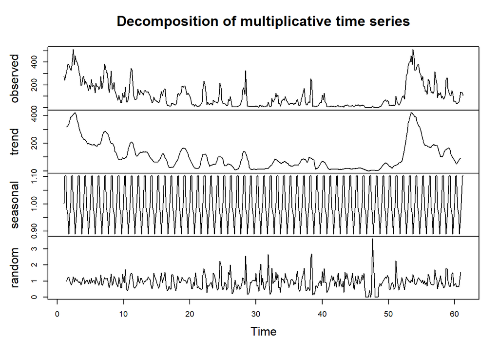

```r
plot(oralb_daily_multiplicative)
```

The graphs above show the trend, seasonal and random components of the multiplicative and additive decomposition. Since there is 0 mean assumption in the continuation of the study, we will continue on the ‘additive’ model.

```r
test1=ur.kpss(oralb_daily_additive$random, use.lag="7")
summary(test1)
```

```
##
## #######################
## # KPSS Unit Root Test #
## #######################
##
## Test is of type: mu with 7 lags.
##
## Value of test-statistic is: 0.0205
##
## Critical value for a significance level of:
##                 10pct  5pct 2.5pct  1pct
## critical values 0.347 0.463  0.574 0.739
```

```r
test2=ur.kpss(oralb_daily_multiplicative$random, use.lag="7")
summary(test2)
```

```
##
## #######################
## # KPSS Unit Root Test #
## #######################
##
## Test is of type: mu with 7 lags.
##
## Value of test-statistic is: 0.1197
##
## Critical value for a significance level of:
##                 10pct  5pct 2.5pct  1pct
## critical values 0.347 0.463  0.574 0.739
```

We can see that the additive model is better by applying the kpss test.

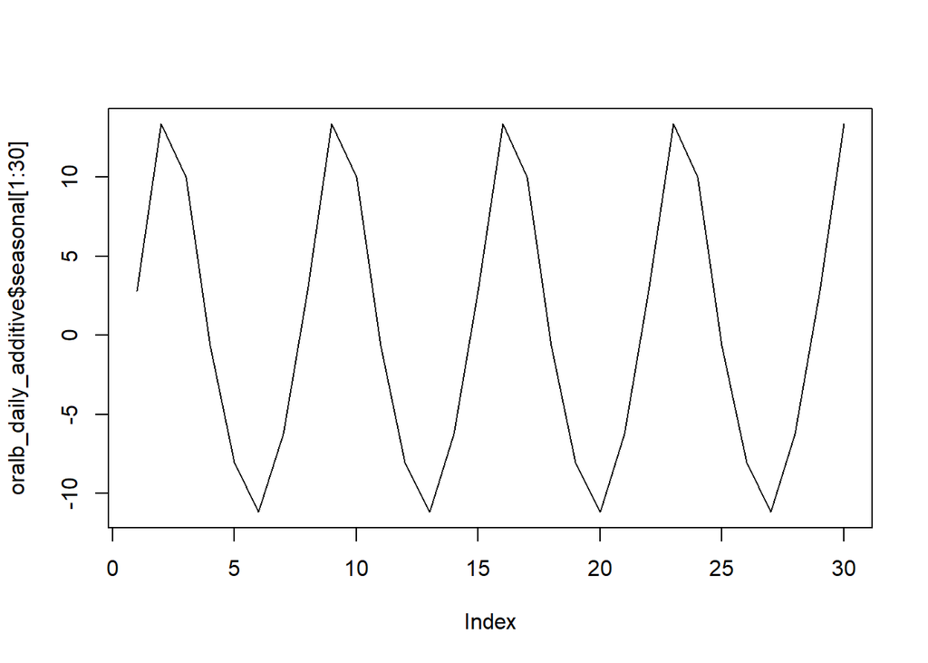

```r
plot(oralb_daily_additive$seasonal[1:30], type='l')
```

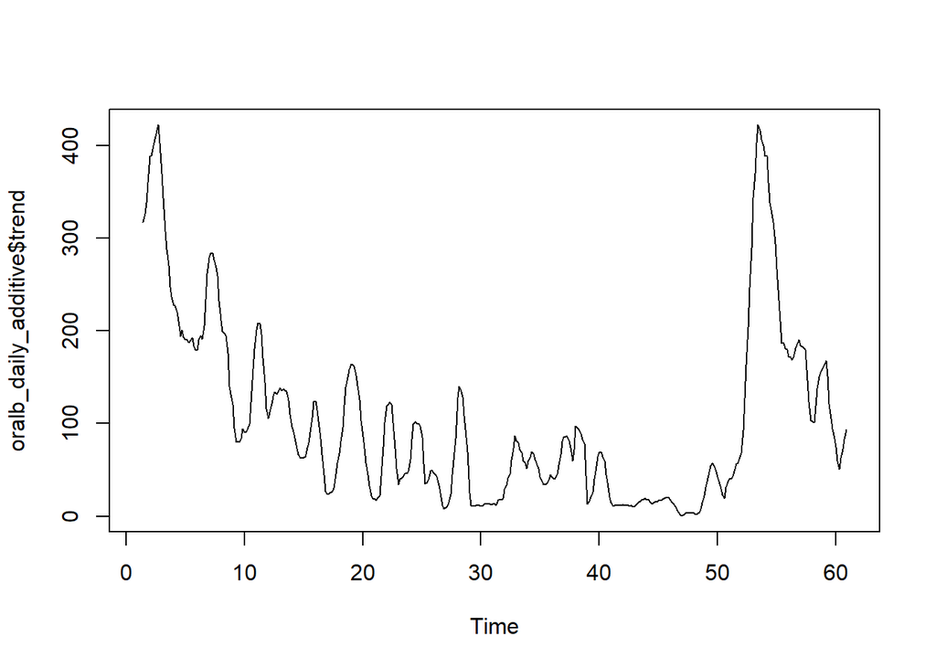

```r
plot(oralb_daily_additive$trend, type='l')
```

# ARIMA Model

To decide on the parameters of ARIMA model, autocorrelation and partial autocorrelation of the random component of additive model are investigated.

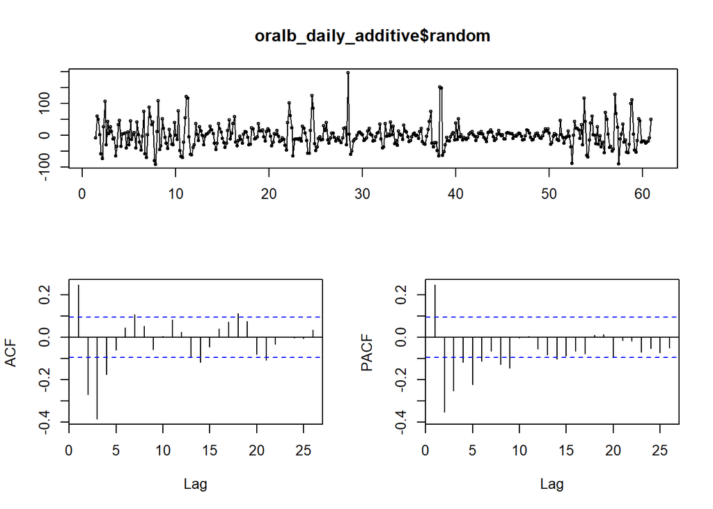

```r
tsdisplay(oralb_daily_additive$random, na.action = na.omit)
```

As can be seen from the graphs there is significant negative autocorrelation in lag 3 at ACF and partial autocorrelation decreased significantly after lag 3 in PACF therefore parameters would be selected as (3,0,3)

```r
oralb_model<-arima(oralb_daily_additive$random, order = c(3,0,3))
AIC(oralb_model)
```

```
## [1] 4013.163
```

```r
oralb_model2<-arima(oralb_daily_additive$random, order = c(2,0,3))
AIC(oralb_model2)
```

```
## [1] 4013.536
```

Model 1 is better in terms of AIC values, therefore it is chosen to construct the ARIMA model.

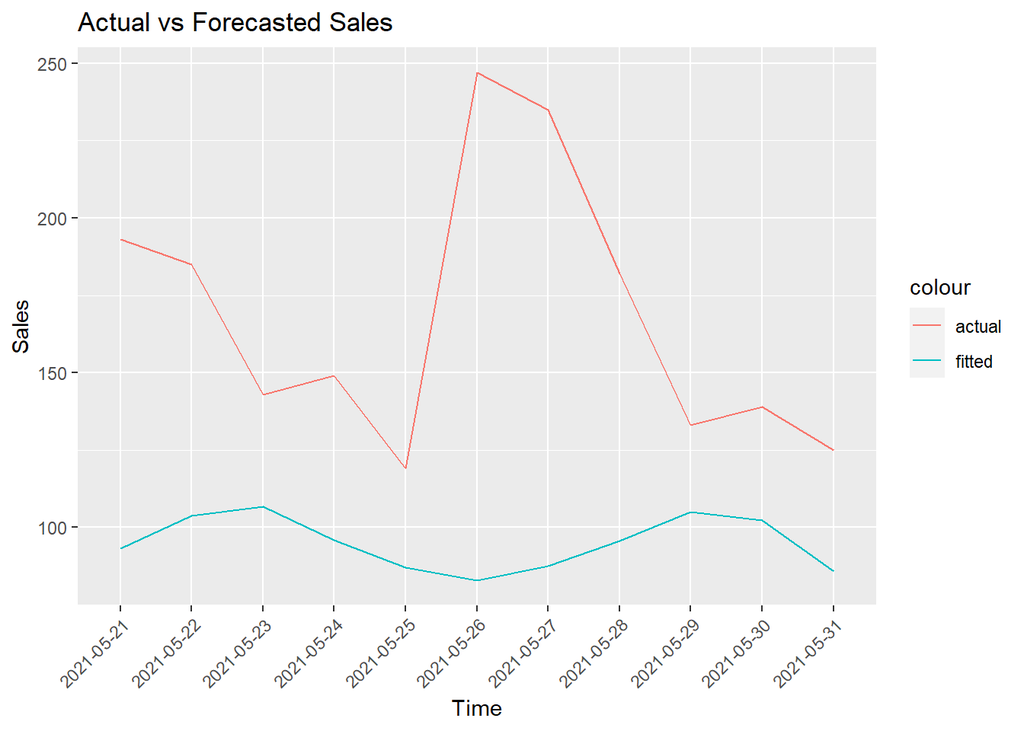

```r
model_forecast_error <- predict(oralb_model, n.ahead = 11)$pred
last_trend_value <-tail(oralb_daily_additive$trend[!is.na(oralb_daily_additive$trend)],1)
seasonality=oralb_daily_additive$seasonal[295:305]
oralb_arima_forecast=model_forecast_error+seasonality+last_trend_value
oralb_daily_te$forecast<-paste(oralb_arima_forecast)
oralb_daily_te$forecast<-as.numeric(oralb_daily_te$forecast)
ggplot(oralb_daily_te ,aes(x=event_date)) +
        geom_line(aes(y=sold_count,color='actual',group=1)) +
        geom_line(aes(y=forecast,color='fitted',group=1)) + labs(title = "Actual vs Forecasted Sales",
       x = "Time",
       y = "Sales"
       )+
  theme(axis.text.x = element_text(angle = 45, hjust=1))
```

From above plot, it can be seen that we are lowerpredicting, it is mainly due to the constant trend assumption, with the addition of regressors this bias may be decreased.

```r
error_test(oralb_daily_te$sold_count,oralb_daily_te$forecast)
```

```
##    n     mean       sd      bias      mape      mad     wmape       MPE
## 1 11 168.1818 43.75116 0.4345621 0.3988615 73.08545 0.4345621 0.3988615
```

## Regressor Search

To decide on which regressors to use, 3 different linear models are constructed and compared in terms of their error rates.

```r
oralb_lm1<-lm(sold_count~visit_count, data=oralb_daily_tr)
summary(oralb_lm1)
```

```
##
## Call:
## lm(formula = sold_count ~ visit_count, data = oralb_daily_tr)
##
## Residuals:
##     Min      1Q  Median      3Q     Max
## -136.92  -31.11  -15.12   20.53  284.88
##
## Coefficients:
##              Estimate Std. Error t value Pr(>|t|)
## (Intercept) 4.012e+01  3.184e+00   12.60   <2e-16 ***
## visit_count 2.539e-02  6.977e-04   36.39   <2e-16 ***
## ---
## Signif. codes:  0 '***' 0.001 '**' 0.01 '*' 0.05 '.' 0.1 ' ' 1
##
## Residual standard error: 53.76 on 421 degrees of freedom
## Multiple R-squared:  0.7588, Adjusted R-squared:  0.7582
## F-statistic:  1324 on 1 and 421 DF,  p-value: < 2.2e-16
```

```r
oralb_lm2<-lm(sold_count~category_sold+price, data=oralb_daily_tr)
summary(oralb_lm2)
```

```
##
## Call:
## lm(formula = sold_count ~ category_sold + price, data = oralb_daily_tr)
##
## Residuals:
##     Min      1Q  Median      3Q     Max
## -272.42  -63.83  -29.82   35.03  366.22
##
## Coefficients:
##                 Estimate Std. Error t value Pr(>|t|)
## (Intercept)   -3.427e+02  7.271e+01  -4.713 3.34e-06 ***
## category_sold  5.850e-02  6.532e-03   8.956  < 2e-16 ***
## price          2.889e+00  5.256e-01   5.496 6.84e-08 ***
## ---
## Signif. codes:  0 '***' 0.001 '**' 0.01 '*' 0.05 '.' 0.1 ' ' 1
##
## Residual standard error: 98.59 on 411 degrees of freedom
##   (9 observations deleted due to missingness)
## Multiple R-squared:  0.1912, Adjusted R-squared:  0.1873
## F-statistic: 48.59 on 2 and 411 DF,  p-value: < 2.2e-16
```

```r
oralb_lm3<-lm(sold_count~favored_count+basket_count, data=oralb_daily_tr)
summary(oralb_lm3)
```

```
##
## Call:
## lm(formula = sold_count ~ favored_count + basket_count, data = oralb_daily_tr)
##
## Residuals:
##      Min       1Q   Median       3Q      Max
## -199.718  -11.146   -2.978    9.731  106.912
##
## Coefficients:
##                Estimate Std. Error t value Pr(>|t|)
## (Intercept)    1.444229   2.088369   0.692     0.49
## favored_count -0.041108   0.006253  -6.574 1.46e-10 ***
## basket_count   0.275278   0.007166  38.417  < 2e-16 ***
## ---
## Signif. codes:  0 '***' 0.001 '**' 0.01 '*' 0.05 '.' 0.1 ' ' 1
##
## Residual standard error: 30.24 on 420 degrees of freedom
## Multiple R-squared:  0.9238, Adjusted R-squared:  0.9235
## F-statistic:  2547 on 2 and 420 DF,  p-value: < 2.2e-16
```

```r
oralb_daily_te$forecastlm1<-predict(oralb_lm1,oralb_daily_te)
oralb_daily_te$forecastlm2<-predict(oralb_lm2,oralb_daily_te)
oralb_daily_te$forecastlm3<-predict(oralb_lm3,oralb_daily_te)
error_test(oralb_daily_te$sold_count,oralb_daily_te$forecastlm1)
```

```
##    n     mean       sd       bias      mape      mad     wmape        MPE
## 1 11 168.1818 43.75116 -0.1508056 0.2329157 35.49989 0.2110804 -0.1909632
```

```r
error_test(oralb_daily_te$sold_count,oralb_daily_te$forecastlm2)
```

```
##    n     mean       sd      bias     mape      mad     wmape      MPE
## 1 11 168.1818 43.75116 0.3330924 0.287421 56.02009 0.3330924 0.287421
```

```r
error_test(oralb_daily_te$sold_count,oralb_daily_te$forecastlm3)
```

```
##    n     mean       sd       bias       mape      mad      wmape         MPE
## 1 11 168.1818 43.75116 0.01735187 0.08558349 14.44366 0.08588124 0.000817934
```

Model 3 WMAPE is much lower than the wmape of the ARIMA model. Favored count and basket count will be added to the model.

## ARIMAX Model

```r
oralb_xreg1<-cbind(oralb_daily_tr$favored_count,
                  oralb_daily_tr$basket_count)
oralb_xreg2<-cbind(oralb_daily_te$favored_count,
                  oralb_daily_te$basket_count)
oralb_arimax<-Arima(oralb_ts_daily,xreg=as.matrix(oralb_xreg1),order=c(3,0,3))
oralb_daily_te$forecastarimax<-forecast(oralb_arimax,xreg=as.matrix(oralb_xreg2))$mean
error_test(oralb_daily_te$sold_count,oralb_daily_te$forecastarimax)
```

```
##    n     mean       sd        bias      mape      mad     wmape         MPE
## 1 11 168.1818 43.75116 0.001742601 0.1105497 17.92261 0.1065669 -0.02128778
```

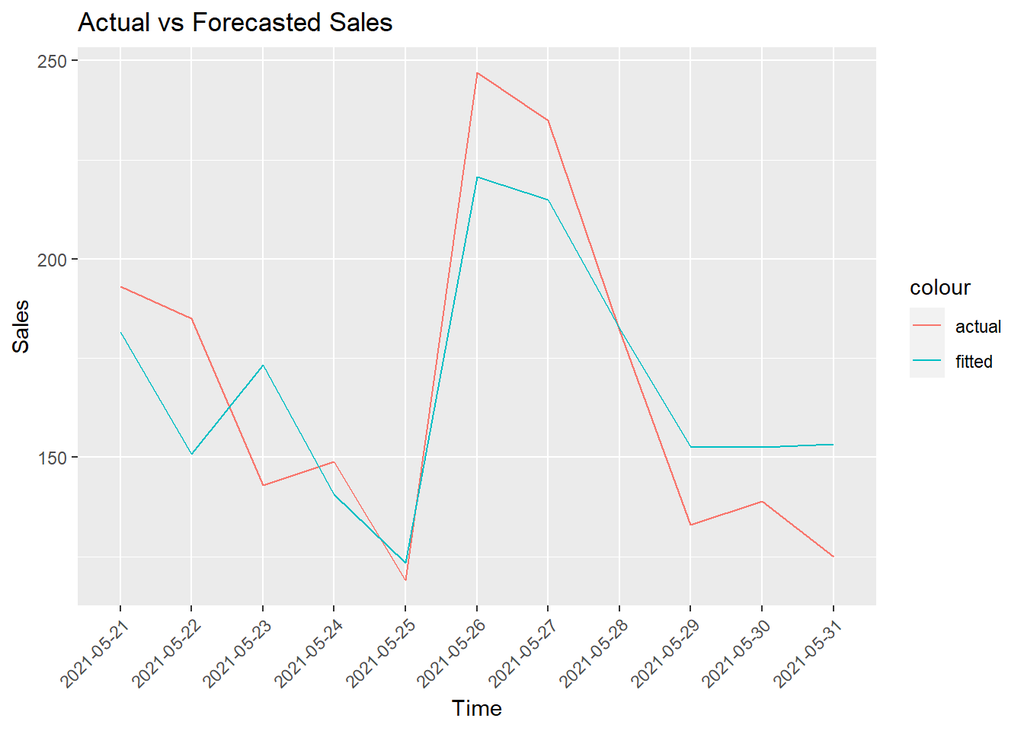

```r
ggplot(oralb_daily_te ,aes(x=event_date)) +
        geom_line(aes(y=sold_count,color='actual',group=1)) +
        geom_line(aes(y=forecastarimax,color='fitted',group=1)) + labs(title = "Actual vs Forecasted Sales",
       x = "Time",
       y = "Sales"
       )+
  theme(axis.text.x = element_text(angle = 45, hjust=1))
```

Above plot shows the fitted values of the last model. Model fits well with the actual values.

# Altınyıldız Classics Coat

## Decomposition

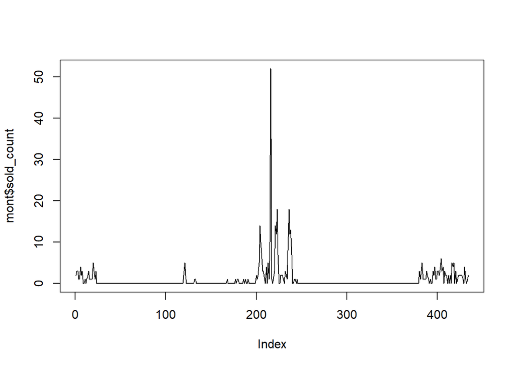

```r
mont<-subset(alldata, alldata$product_content_id==48740784)
mont_daily_tr<-mont[mont$event_date<"2021-05-21"]
mont_daily_te<-mont[mont$event_date>="2021-05-21"]
plot(mont$sold_count, type = 'l')
```

Plot above shows sold counts of Altınyıldız Classics coat.

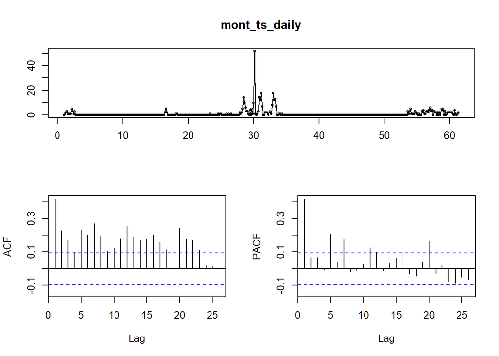

```r
mont_ts_daily<-ts(mont_daily_tr$sold_count, freq=7)
tsdisplay(mont_ts_daily)
```

Necessary data manipulations were made to create a 7 frequency time series object. In lag 7 we see autocorrelation and as a result there is seasonality at the weekly level.

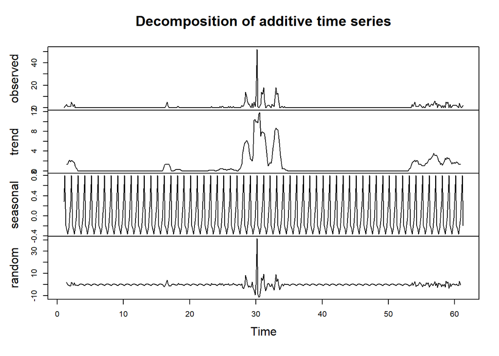

```r
mont_daily_additive<-decompose(mont_ts_daily, type ="additive")
mont_daily_multiplicative<-decompose(mont_ts_daily, type ="multiplicative")
plot(mont_daily_additive)
```

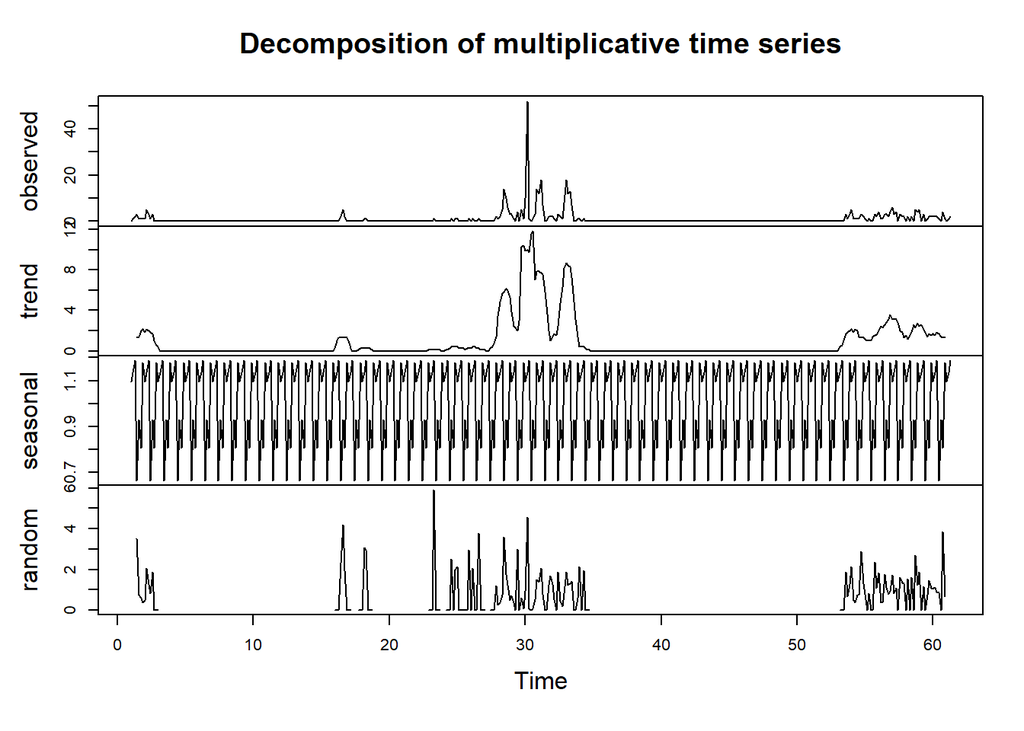

```r
plot(mont_daily_multiplicative)
```

The graphs above show the trend, seasonal and random components of the multiplicative and additive decomposition. Since there is 0 mean assumption in the continuation of the study, we will continue on the ‘additive’ model.

```r
test1=ur.kpss(mont_daily_additive$random, use.lag="7")
summary(test1)
```

```
##
## #######################
## # KPSS Unit Root Test #
## #######################
##
## Test is of type: mu with 7 lags.
##
## Value of test-statistic is: 0.0105
##
## Critical value for a significance level of:
##                 10pct  5pct 2.5pct  1pct
## critical values 0.347 0.463  0.574 0.739
```

```r
test2=ur.kpss(mont_daily_multiplicative$random, use.lag="7")
summary(test2)
```

```
##
## #######################
## # KPSS Unit Root Test #
## #######################
##
## Test is of type: mu with 7 lags.
##
## Value of test-statistic is: 0.1928
##
## Critical value for a significance level of:
##                 10pct  5pct 2.5pct  1pct
## critical values 0.347 0.463  0.574 0.739
```

We can see that the additive model is better by applying the kpss test.

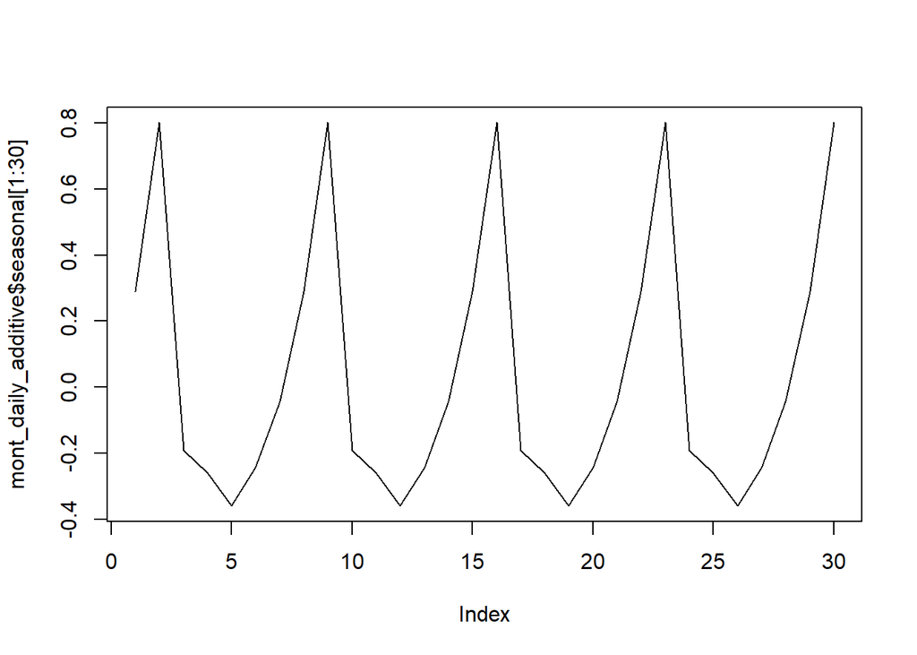

```r
plot(mont_daily_additive$seasonal[1:30], type='l')
```

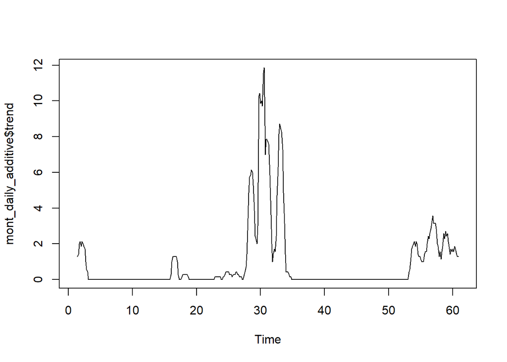

```r
plot(mont_daily_additive$trend, type='l')
```

## ARIMA Model

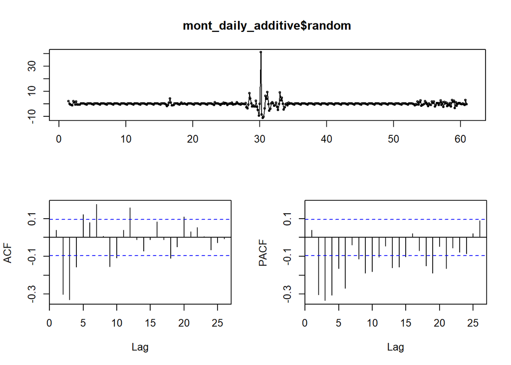

```r
tsdisplay(mont_daily_additive$random, na.action = na.omit)
```

```r
mont_model<-arima(mont_daily_additive$random, order = c(3,0,4))
AIC(mont_model)
```

```
## [1] 1740.003
```

```r
mont_model2<-arima(mont_daily_additive$random, order = c(2,0,4))
AIC(mont_model2)
```

```
## [1] 1735.861
```

Model 2 is better in terms of AIC values, therefore it is chosen to perform the forecast.

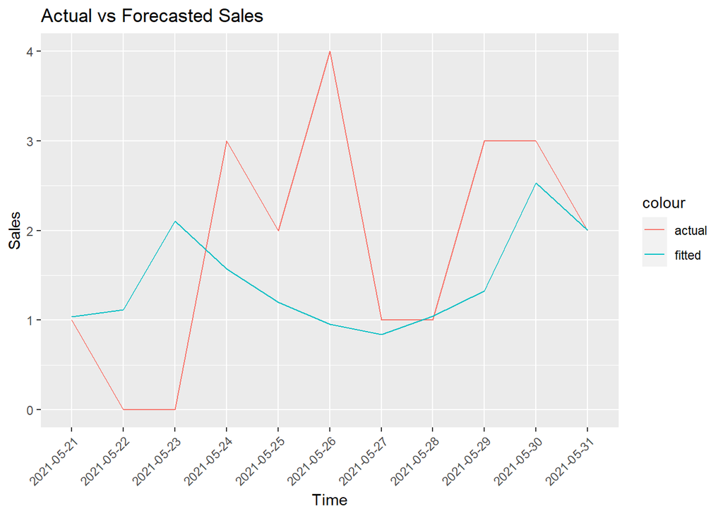

```r
model_forecast_error <- predict(mont_model2, n.ahead = 11)$pred
last_trend_value <-tail(mont_daily_additive$trend[!is.na(mont_daily_additive$trend)],1)
seasonality=mont_daily_additive$seasonal[295:305]
mont_arima_forecast=model_forecast_error+seasonality+last_trend_value
mont_daily_te$forecast<-paste(mont_arima_forecast)
mont_daily_te$forecast<-as.numeric(mont_daily_te$forecast)
ggplot(mont_daily_te ,aes(x=event_date)) +
        geom_line(aes(y=sold_count,color='actual',group=1)) +
        geom_line(aes(y=forecast,color='fitted',group=1)) + labs(title = "Actual vs Forecasted Sales",
       x = "Time",
       y = "Sales"
       )+
  theme(axis.text.x = element_text(angle = 45, hjust=1))
```

```r
error_test(mont_daily_te$sold_count,mont_daily_te$forecast)
```

```
##    n     mean      sd      bias mape       mad     wmape  MPE
## 1 11 1.818182 1.32802 0.2138054  Inf 0.9883341 0.5435837 -Inf
```

## Regressor Search

We constructed three different linear model and compared the wmape values to decide on the regressors that will be added to ARIMA model

```r
mont_lm1<-lm(sold_count~visit_count, data=mont_daily_tr)
summary(mont_lm1)
```

```
##
## Call:
## lm(formula = sold_count ~ visit_count, data = mont_daily_tr)
##
## Residuals:
##    Min     1Q Median     3Q    Max
## -2.369 -0.733 -0.726 -0.726 51.274
##
## Coefficients:
##             Estimate Std. Error t value Pr(>|t|)
## (Intercept) 0.726157   0.176628   4.111 4.73e-05 ***
## visit_count 0.007300   0.002406   3.034  0.00256 **
## ---
## Signif. codes:  0 '***' 0.001 '**' 0.01 '*' 0.05 '.' 0.1 ' ' 1
##
## Residual standard error: 3.342 on 421 degrees of freedom
## Multiple R-squared:  0.0214, Adjusted R-squared:  0.01907
## F-statistic: 9.205 on 1 and 421 DF,  p-value: 0.002563
```

```r
mont_lm2<-lm(sold_count~category_sold+price, data=mont_daily_tr)
summary(mont_lm2)
```

```
##
## Call:
## lm(formula = sold_count ~ category_sold + price, data = mont_daily_tr)
##
## Residuals:
##    Min     1Q Median     3Q    Max
## -3.997 -2.650 -0.561  0.457 47.679
##
## Coefficients:
##                Estimate Std. Error t value Pr(>|t|)
## (Intercept)   0.4601334  1.1018683   0.418  0.67700
## category_sold 0.0001040  0.0007311   0.142  0.88711
## price         0.0054312  0.0018195   2.985  0.00344 **
## ---
## Signif. codes:  0 '***' 0.001 '**' 0.01 '*' 0.05 '.' 0.1 ' ' 1
##
## Residual standard error: 5.515 on 119 degrees of freedom
##   (301 observations deleted due to missingness)
## Multiple R-squared:  0.06983,    Adjusted R-squared:  0.0542
## F-statistic: 4.467 on 2 and 119 DF,  p-value: 0.01347
```

```r
mont_lm3<-lm(sold_count~favored_count+basket_count, data=mont_daily_tr)
summary(mont_lm3)
```

```
##
## Call:
## lm(formula = sold_count ~ favored_count + basket_count, data = mont_daily_tr)
##
## Residuals:
##      Min       1Q   Median       3Q      Max
## -13.6815  -0.0512   0.0736   0.0736   9.8613
##
## Coefficients:
##                Estimate Std. Error t value Pr(>|t|)
## (Intercept)   -0.073612   0.082777  -0.889    0.374
## favored_count  0.007647   0.014186   0.539    0.590
## basket_count   0.170900   0.004176  40.928   <2e-16 ***
## ---
## Signif. codes:  0 '***' 0.001 '**' 0.01 '*' 0.05 '.' 0.1 ' ' 1
##
## Residual standard error: 1.504 on 420 degrees of freedom
## Multiple R-squared:  0.8022, Adjusted R-squared:  0.8013
## F-statistic: 851.9 on 2 and 420 DF,  p-value: < 2.2e-16
```

```r
mont_daily_te$forecastlm1<-predict(mont_lm1,mont_daily_te)
mont_daily_te$forecastlm2<-predict(mont_lm2,mont_daily_te)
mont_daily_te$forecastlm3<-predict(mont_lm3,mont_daily_te)
error_test(mont_daily_te$sold_count,mont_daily_te$forecastlm1)
```

```
##    n     mean      sd       bias mape       mad     wmape  MPE
## 1 11 1.818182 1.32802 0.08782079  Inf 0.9399347 0.5169641 -Inf
```

```r
error_test(mont_daily_te$sold_count,mont_daily_te$forecastlm2)
```

```
##    n     mean      sd bias mape mad wmape MPE
## 1 11 1.818182 1.32802   NA   NA  NA    NA  NA
```

```r
error_test(mont_daily_te$sold_count,mont_daily_te$forecastlm3)
```

```
##    n     mean      sd      bias mape      mad     wmape  MPE
## 1 11 1.818182 1.32802 0.1578252  Inf 1.016172 0.5588943 -Inf
```

Model 1 performed better wmape. Despite its adjusted R-square value Model 1 resulted better at wmape therefore discount days information and visit counts will be used as regressors.

# ARIMAX Model

```r
mont_xreg1<-cbind(mont_daily_tr$is.discount_days,
                  mont_daily_tr$visit_count)
mont_xreg2<-cbind(mont_daily_te$is.discount_days,
                  mont_daily_te$visit_count)
mont_arimax<-Arima(mont_ts_daily,xreg=as.matrix(mont_xreg1),order=c(2,0,4))
mont_daily_te$forecastarimax<-forecast(mont_arimax,xreg=as.matrix(mont_xreg2))$mean
error_test(mont_daily_te$sold_count,mont_daily_te$forecastarimax)
```

```
##    n     mean      sd        bias mape      mad     wmape  MPE
## 1 11 1.818182 1.32802 -0.03562958  Inf 1.024367 0.5634019 -Inf
```

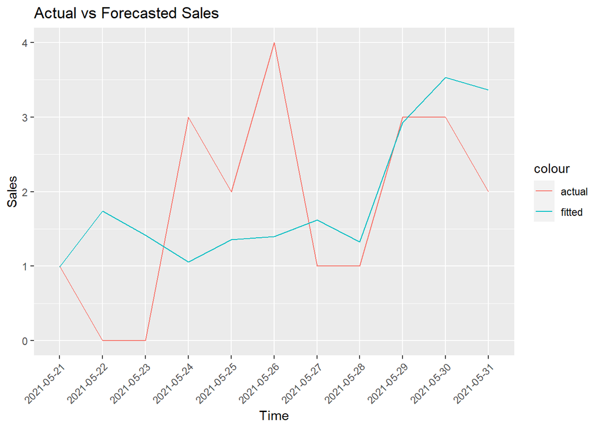

```r
ggplot(mont_daily_te ,aes(x=event_date)) +
        geom_line(aes(y=sold_count,color='actual',group=1)) +
        geom_line(aes(y=forecastarimax,color='fitted',group=1)) + labs(title = "Actual vs Forecasted Sales",
       x = "Time",
       y = "Sales"
       )+
 theme(axis.text.x = element_text(angle = 45, hjust=1))
```

The chart above shows the estimated and actual values with the ARIMAX model. The model was not much affected by the addition of regressors.

# Sleepy Baby Wet Wipe

## Decomposition

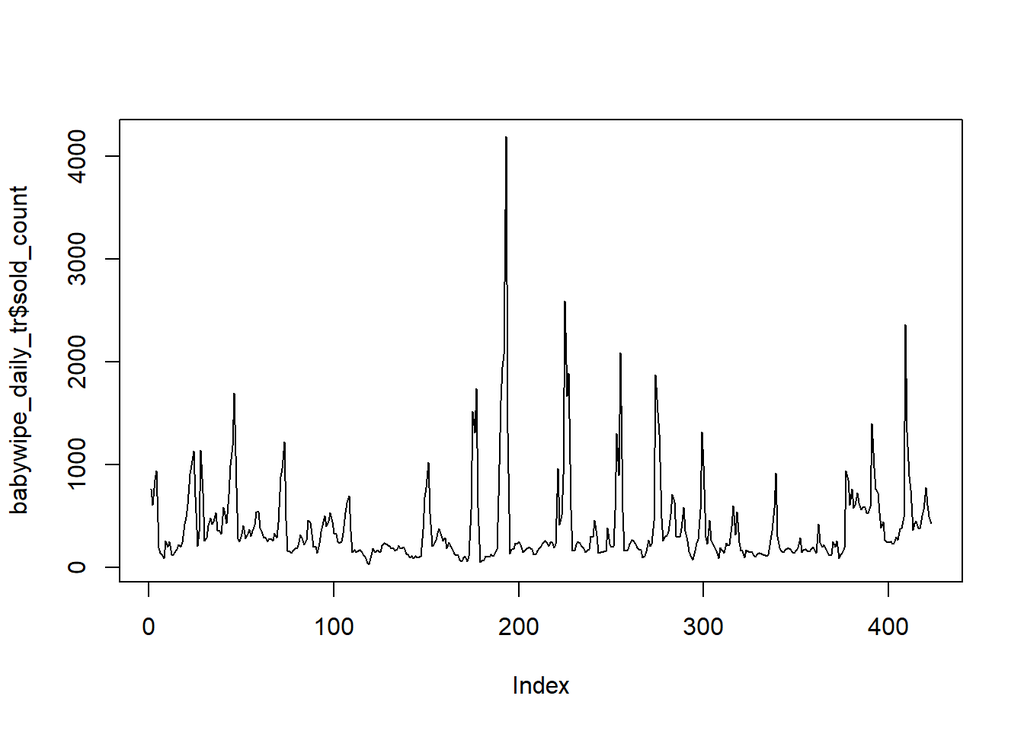

```r
babywipe<-subset(alldata, alldata$product_content_id==4066298)
babywipe_daily_tr<-babywipe[babywipe$event_date<"2021-05-21"]
babywipe_daily_te<-babywipe[babywipe$event_date>="2021-05-21"]
plot(babywipe_daily_tr$sold_count, type ='l')
```

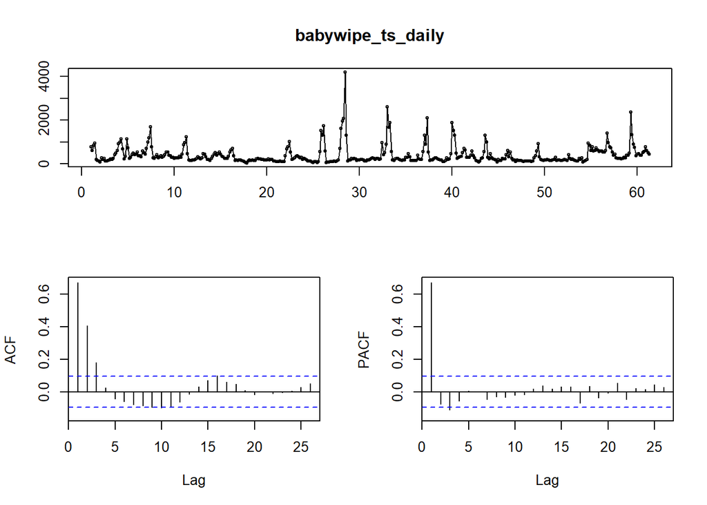

```r
babywipe_ts_daily<-ts(babywipe_daily_tr$sold_count, freq=7)
tsdisplay(babywipe_ts_daily)
```

Autocorrelation 3 value is above threshold and PACF shows significant correlation at lag 1.

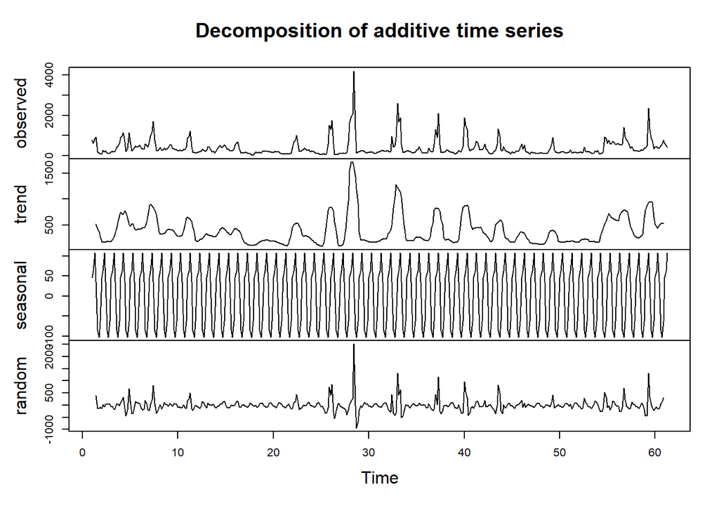

```r
babywipe_daily_additive<-decompose(babywipe_ts_daily, type ="additive")
babywipe_daily_multiplicative<-decompose(babywipe_ts_daily, type ="multiplicative")
plot(babywipe_daily_additive)
```

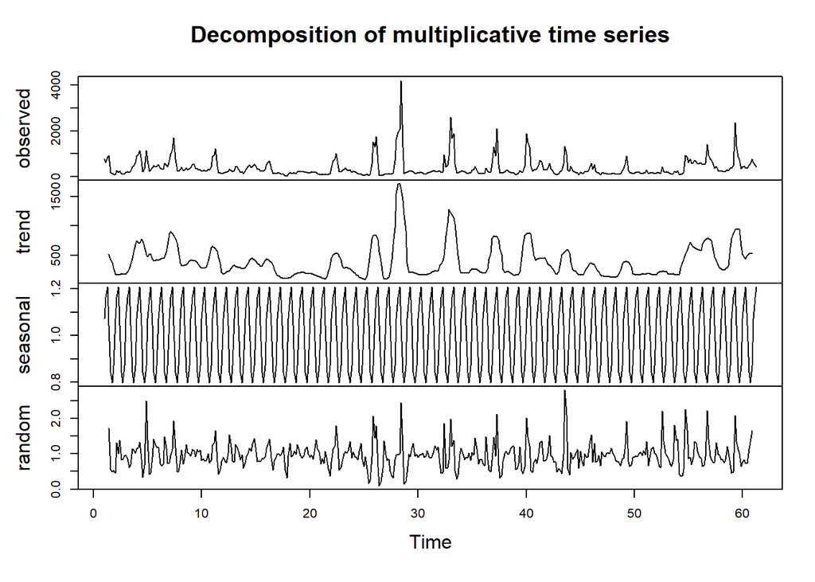

```r
plot(babywipe_daily_multiplicative)
```

The graphs above show the trend, seasonal and random components of the multiplicative and additive decomposition. Since there is 0 mean assumption in the continuation of the study, we will continue on the ‘additive’ model.

```r
test17=ur.kpss(babywipe_daily_additive$random, use.lag="7")
summary(test17)
```

```
##
## #######################
## # KPSS Unit Root Test #
## #######################
##
## Test is of type: mu with 7 lags.
##
## Value of test-statistic is: 0.0109
##
## Critical value for a significance level of:
##                 10pct  5pct 2.5pct  1pct
## critical values 0.347 0.463  0.574 0.739
```

```r
test18=ur.kpss(babywipe_daily_multiplicative$random, use.lag="7")
summary(test18)
```

```
##
## #######################
## # KPSS Unit Root Test #
## #######################
##
## Test is of type: mu with 7 lags.
##
## Value of test-statistic is: 0.1595
##
## Critical value for a significance level of:
##                 10pct  5pct 2.5pct  1pct
## critical values 0.347 0.463  0.574 0.739
```

We can see that the additive model is better by applying the kpss test.

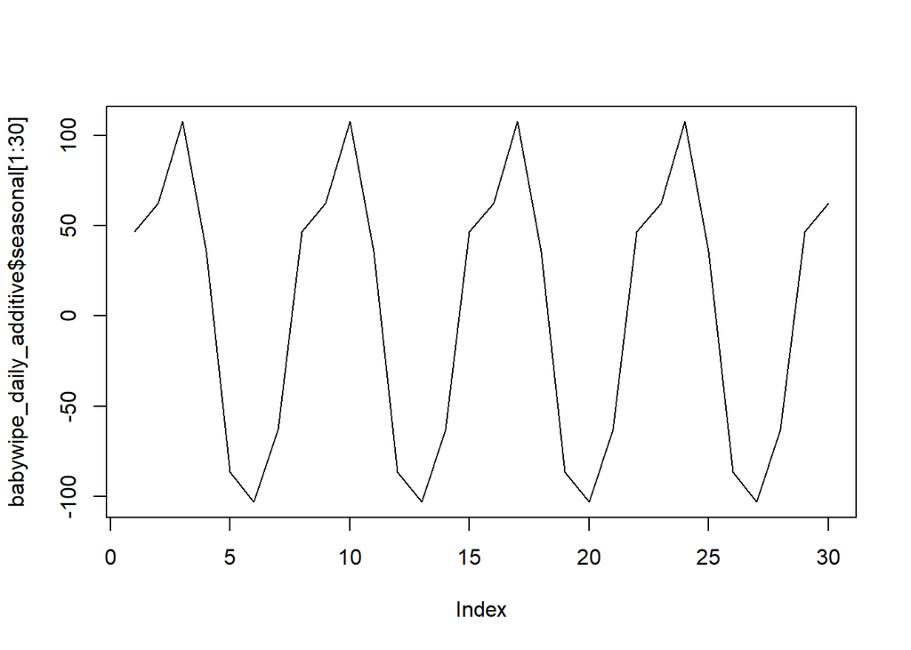

```r
plot(babywipe_daily_additive$seasonal[1:30], type='l')
```

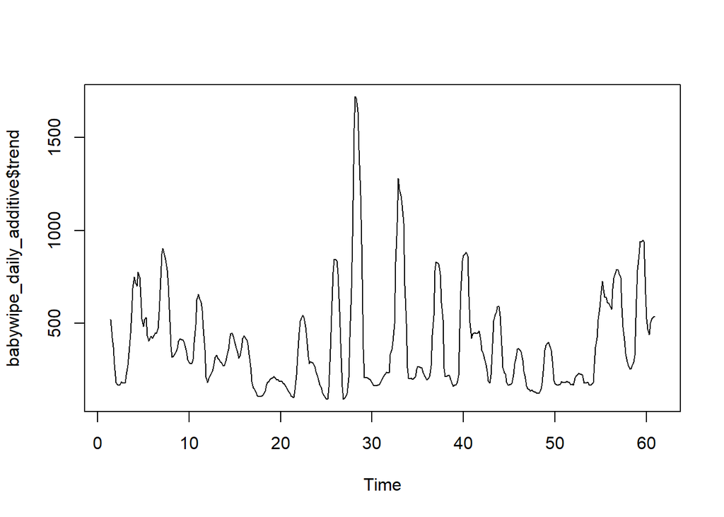

```r
plot(babywipe_daily_additive$trend, type='l')
```

## ARIMA Model

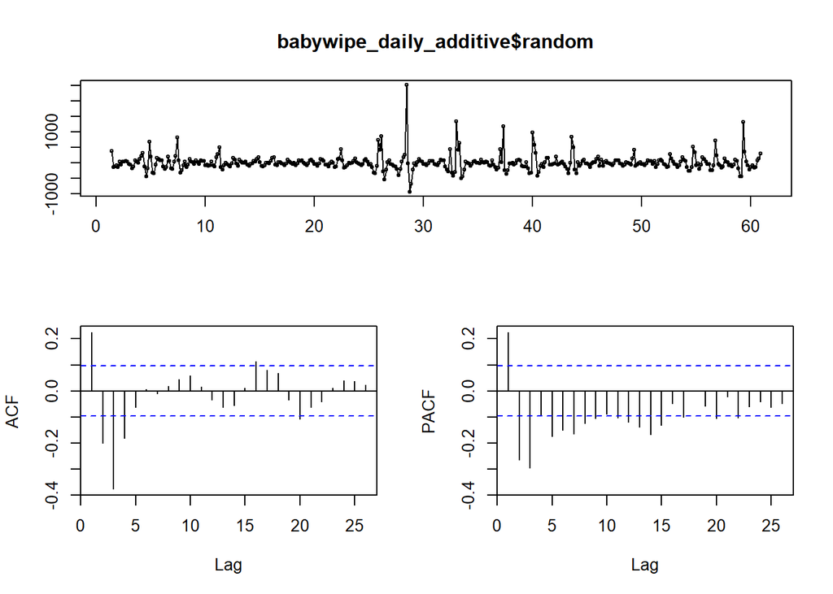

```r
tsdisplay(babywipe_daily_additive$random, na.action = na.omit)
```

ACF grafiğine göre, gecikme 3’te anlamlı bir negatif korelasyon vardır. Dolayısıyla, hareketli ortalama parametresi 3 olmalıdır. Ayrıca, PACF grafiğinden, gecikme 3’ten sonra korelasyonun önemli ölçüde azaldığı, yani AR parametresinin 3 olması gerektiği anlamına gelir.

```r
babywipe_model<-arima(babywipe_daily_additive$random, order = c(3,0,3))
AIC(babywipe_model)
```

```
## [1] 5640.146
```

```r
babywipe_model2<-arima(babywipe_daily_additive$random, order = c(2,0,3))
AIC(babywipe_model2)
```

```
## [1] 5609.456
```

```r
babywipe_model3<-arima(babywipe_daily_additive$random, order = c(1,0,3))
AIC(babywipe_model3)
```

```
## [1] 5656.263
```

Model 2 is better in terms of AIC values, therefore it is chosen.

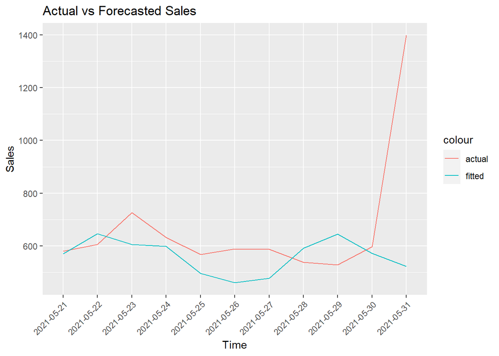

```r
model_forecast_error <- predict(babywipe_model2, n.ahead = 11)$pred
last_trend_value <-tail(babywipe_daily_additive$trend[!is.na(babywipe_daily_additive$trend)],1)
seasonality=babywipe_daily_additive$seasonal[295:305]
babywipe_arima_forecast=model_forecast_error+seasonality+last_trend_value
babywipe_daily_te$forecast<-paste(babywipe_arima_forecast)
babywipe_daily_te$forecast<-as.numeric(babywipe_daily_te$forecast)
ggplot(babywipe_daily_te ,aes(x=event_date)) +
        geom_line(aes(y=sold_count,color='actual',group=1)) +
        geom_line(aes(y=forecast,color='fitted',group=1)) + labs(title = "Actual vs Forecasted Sales",
       x = "Time",
       y = "Sales"
       )+
 theme(axis.text.x = element_text(angle = 45, hjust=1))
```

The chart above shows the 11-day actual and estimated values with the ARIMA model we built on the decomposed random part. Seasonal effects are clearly visible between actual and favorable values.

```r
error_test(babywipe_daily_te$sold_count,babywipe_daily_te$forecast)
```

```
##    n     mean       sd      bias      mape      mad     wmape        MPE
## 1 11 668.4545 247.6144 0.1582767 0.1658866 144.2131 0.2157411 0.09526073
```

## Regressor Search

```r
babywipe_lm1<-lm(sold_count~visit_count, data=babywipe_daily_tr)
summary(babywipe_lm1)
```

```
##
## Call:
## lm(formula = sold_count ~ visit_count, data = babywipe_daily_tr)
##
## Residuals:
##    Min     1Q Median     3Q    Max
## -312.4 -167.3 -105.7    5.8 3898.2
##
## Coefficients:
##              Estimate Std. Error t value Pr(>|t|)
## (Intercept) 292.78272   22.27795  13.142   <2e-16 ***
## visit_count   0.04169    0.00487   8.562   <2e-16 ***
## ---
## Signif. codes:  0 '***' 0.001 '**' 0.01 '*' 0.05 '.' 0.1 ' ' 1
##
## Residual standard error: 386.1 on 421 degrees of freedom
## Multiple R-squared:  0.1483, Adjusted R-squared:  0.1463
## F-statistic:  73.3 on 1 and 421 DF,  p-value: < 2.2e-16
```

```r
babywipe_lm2<-lm(sold_count~category_sold+price, data=babywipe_daily_tr)
summary(babywipe_lm2)
```

```
##
## Call:
## lm(formula = sold_count ~ category_sold + price, data = babywipe_daily_tr)
##
## Residuals:
##     Min      1Q  Median      3Q     Max
## -645.69  -99.13    6.01   78.36 1421.04
##
## Coefficients:
##                 Estimate Std. Error t value Pr(>|t|)
## (Intercept)    1.026e+03  1.926e+02   5.329 1.62e-07 ***
## category_sold  2.022e-01  6.362e-03  31.789  < 2e-16 ***
## price         -1.434e+01  2.630e+00  -5.453 8.48e-08 ***
## ---
## Signif. codes:  0 '***' 0.001 '**' 0.01 '*' 0.05 '.' 0.1 ' ' 1
##
## Residual standard error: 188.1 on 420 degrees of freedom
## Multiple R-squared:  0.7983, Adjusted R-squared:  0.7973
## F-statistic: 831.2 on 2 and 420 DF,  p-value: < 2.2e-16
```

```r
babywipe_lm3<-lm(sold_count~price+favored_count+basket_count+category_sold, data=babywipe_daily_tr)
summary(babywipe_lm3)
```

```
##
## Call:
## lm(formula = sold_count ~ price + favored_count + basket_count +
##     category_sold, data = babywipe_daily_tr)
##
## Residuals:
##     Min      1Q  Median      3Q     Max
## -671.37  -41.41    9.75   51.10 1210.35
##
## Coefficients:
##                 Estimate Std. Error t value Pr(>|t|)
## (Intercept)   109.311879 121.597022   0.899    0.369
## price          -1.943378   1.658928  -1.171    0.242
## favored_count  -0.372958   0.023163 -16.102   <2e-16 ***
## basket_count    0.292624   0.010945  26.735   <2e-16 ***
## category_sold   0.106217   0.005684  18.686   <2e-16 ***
## ---
## Signif. codes:  0 '***' 0.001 '**' 0.01 '*' 0.05 '.' 0.1 ' ' 1
##
## Residual standard error: 114 on 418 degrees of freedom
## Multiple R-squared:  0.9263, Adjusted R-squared:  0.9256
## F-statistic:  1314 on 4 and 418 DF,  p-value: < 2.2e-16
```

```r
babywipe_lm4<-lm(sold_count~favored_count+basket_count+category_sold, data=babywipe_daily_tr)
summary(babywipe_lm4)
```

```
##
## Call:
## lm(formula = sold_count ~ favored_count + basket_count + category_sold,
##     data = babywipe_daily_tr)
##
## Residuals:
##     Min      1Q  Median      3Q     Max
## -677.55  -45.41   11.14   48.75 1196.35
##
## Coefficients:
##                 Estimate Std. Error t value Pr(>|t|)
## (Intercept)   -32.792134   8.434867  -3.888 0.000118 ***
## favored_count  -0.376999   0.022914 -16.453  < 2e-16 ***
## basket_count    0.296185   0.010519  28.157  < 2e-16 ***
## category_sold   0.107245   0.005619  19.087  < 2e-16 ***
## ---
## Signif. codes:  0 '***' 0.001 '**' 0.01 '*' 0.05 '.' 0.1 ' ' 1
##
## Residual standard error: 114 on 419 degrees of freedom
## Multiple R-squared:  0.9261, Adjusted R-squared:  0.9256
## F-statistic:  1750 on 3 and 419 DF,  p-value: < 2.2e-16
```

```r
babywipe_daily_te$forecastlm1<-predict(babywipe_lm1,babywipe_daily_te)
babywipe_daily_te$forecastlm2<-predict(babywipe_lm2,babywipe_daily_te)
babywipe_daily_te$forecastlm3<-predict(babywipe_lm3,babywipe_daily_te)
babywipe_daily_te$forecastlm4<-predict(babywipe_lm4,babywipe_daily_te)
error_test(babywipe_daily_te$sold_count,babywipe_daily_te$forecastlm1)
```

```
##    n     mean       sd       bias       mape      mad     wmape       MPE
## 1 11 668.4545 247.6144 0.09876726 0.08876069 70.63952 0.1056759 0.0800143
```

```r
error_test(babywipe_daily_te$sold_count,babywipe_daily_te$forecastlm2)
```

```
##    n     mean       sd     bias      mape      mad     wmape       MPE
## 1 11 668.4545 247.6144 0.159808 0.2812389 166.9877 0.2498116 0.1745887
```

```r
error_test(babywipe_daily_te$sold_count,babywipe_daily_te$forecastlm3)
```

```
##    n     mean       sd        bias     mape      mad     wmape         MPE
## 1 11 668.4545 247.6144 -0.03118253 0.136756 86.56415 0.1294989 -0.02281145
```

```r
error_test(babywipe_daily_te$sold_count,babywipe_daily_te$forecastlm4)
```

```
##    n     mean       sd        bias      mape      mad     wmape         MPE
## 1 11 668.4545 247.6144 -0.04000832 0.1383669 87.82213 0.1313809 -0.03236746
```

## ARIMAX Model

```r
babywipe_xreg1<-cbind(babywipe_daily_tr$favored_count,
                  babywipe_daily_tr$basket_count,
                  babywipe_daily_tr$category_sold,
                  babywipe_daily_tr$is.discount_days)
babywipe_xreg2<-cbind(babywipe_daily_te$favored_count,
                  babywipe_daily_te$basket_count,
                  babywipe_daily_te$category_sold,
                  babywipe_daily_te$is.discount_days)
babywipe_arimax<-Arima(babywipe_ts_daily,xreg=as.matrix(babywipe_xreg1),order=c(2,0,3))
babywipe_daily_te$forecastarimax<-forecast(babywipe_arimax,xreg=as.matrix(babywipe_xreg2))$mean
error_test(babywipe_daily_te$sold_count,babywipe_daily_te$forecastarimax)
```

```
##    n     mean       sd      bias      mape      mad     wmape       MPE
## 1 11 668.4545 247.6144 0.1674215 0.2237111 134.5835 0.2013353 0.1948495
```

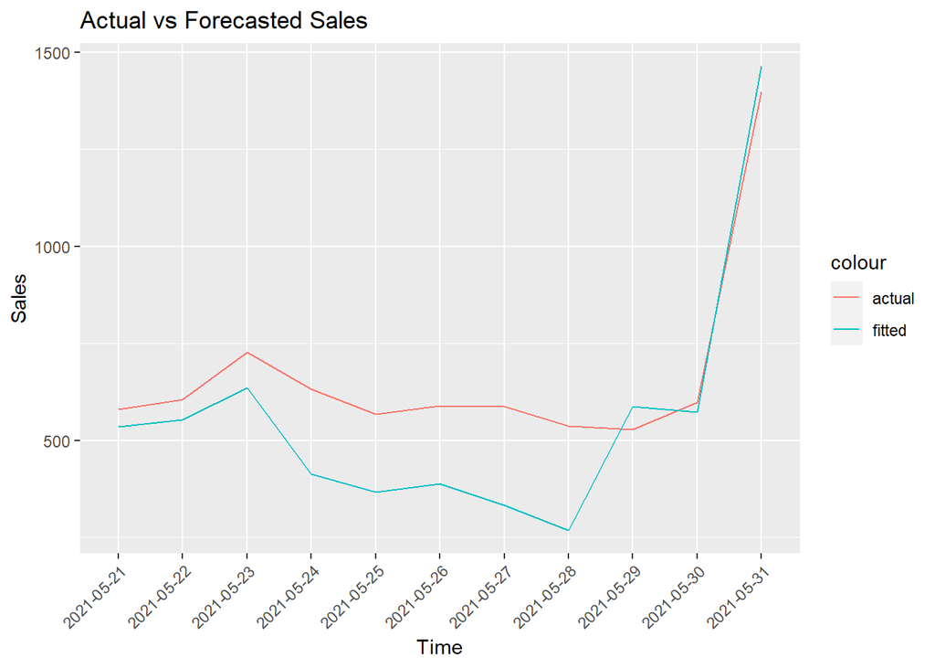

```r
ggplot(babywipe_daily_te ,aes(x=event_date)) +
        geom_line(aes(y=sold_count,color='actual',group=1)) +
        geom_line(aes(y=forecastarimax,color='fitted',group=1)) + labs(title = "Actual vs Forecasted Sales",
       x = "Time",
       y = "Sales"
       )+
 theme(axis.text.x = element_text(angle = 45, hjust=1))
```

# La Roche Posey Facial Cleanser

## Decomposition

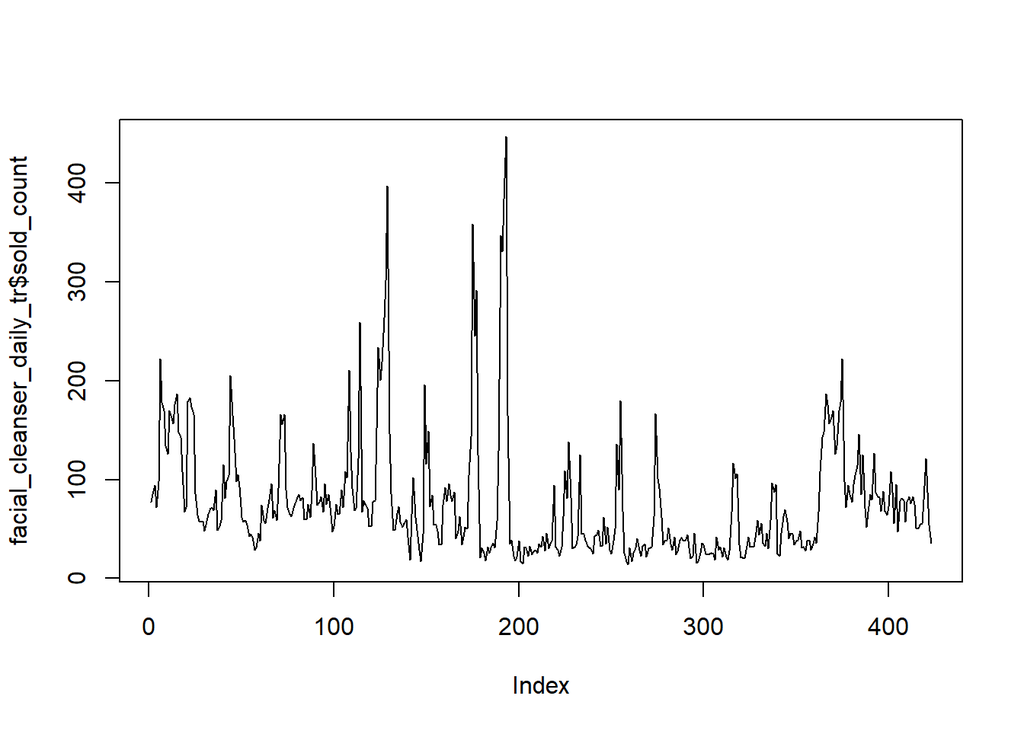

```r
facial_cleanser<-subset(alldata, alldata$product_content_id==85004)
facial_cleanser_daily_tr<-facial_cleanser[facial_cleanser$event_date<"2021-05-21"]
facial_cleanser_daily_te<-facial_cleanser[facial_cleanser$event_date>="2021-05-21"]
plot(facial_cleanser_daily_tr$sold_count, type ='l')
```

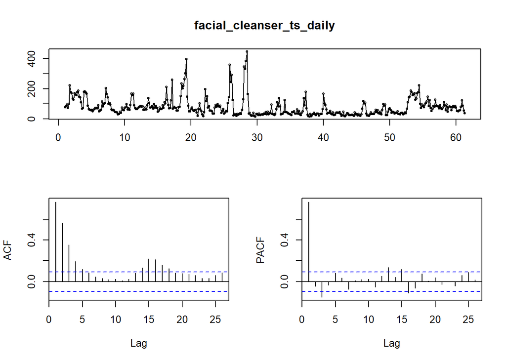

```r
facial_cleanser_ts_daily<-ts(facial_cleanser_daily_tr$sold_count, freq=7)
tsdisplay(facial_cleanser_ts_daily)
```

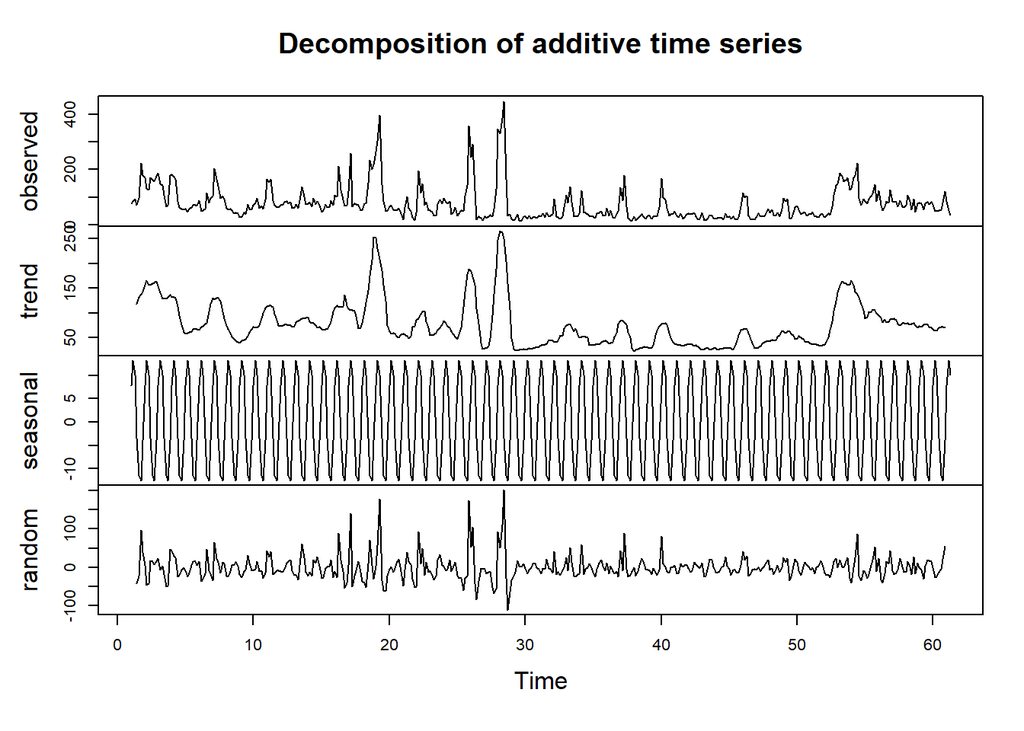

```r
facial_cleanser_daily_additive<-decompose(facial_cleanser_ts_daily, type ="additive")
facial_cleanser_daily_multiplicative<-decompose(facial_cleanser_ts_daily, type ="multiplicative")
plot(facial_cleanser_daily_additive)
```

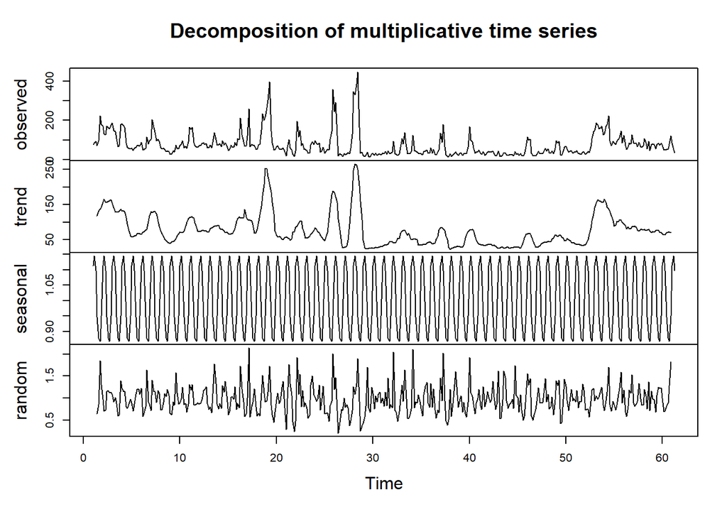

```r
plot(facial_cleanser_daily_multiplicative)
```

The graphs above show the trend, seasonal and random components of the multiplicative and additive decomposition. Since there is 0 mean assumption in the continuation of the study, we will continue on the ‘additive’ model.

```r
test15=ur.kpss(facial_cleanser_daily_additive$random, use.lag="7")
summary(test15)
```

```
##
## #######################
## # KPSS Unit Root Test #
## #######################
##
## Test is of type: mu with 7 lags.
##
## Value of test-statistic is: 0.0106
##
## Critical value for a significance level of:
##                 10pct  5pct 2.5pct  1pct
## critical values 0.347 0.463  0.574 0.739
```

```r
test16=ur.kpss(facial_cleanser_daily_multiplicative$random, use.lag="7")
summary(test16)
```

```
##
## #######################
## # KPSS Unit Root Test #
## #######################
##
## Test is of type: mu with 7 lags.
##
## Value of test-statistic is: 0.1568
##
## Critical value for a significance level of:
##                 10pct  5pct 2.5pct  1pct
## critical values 0.347 0.463  0.574 0.739
```

We can see that the additive model is better by applying the kpss test.

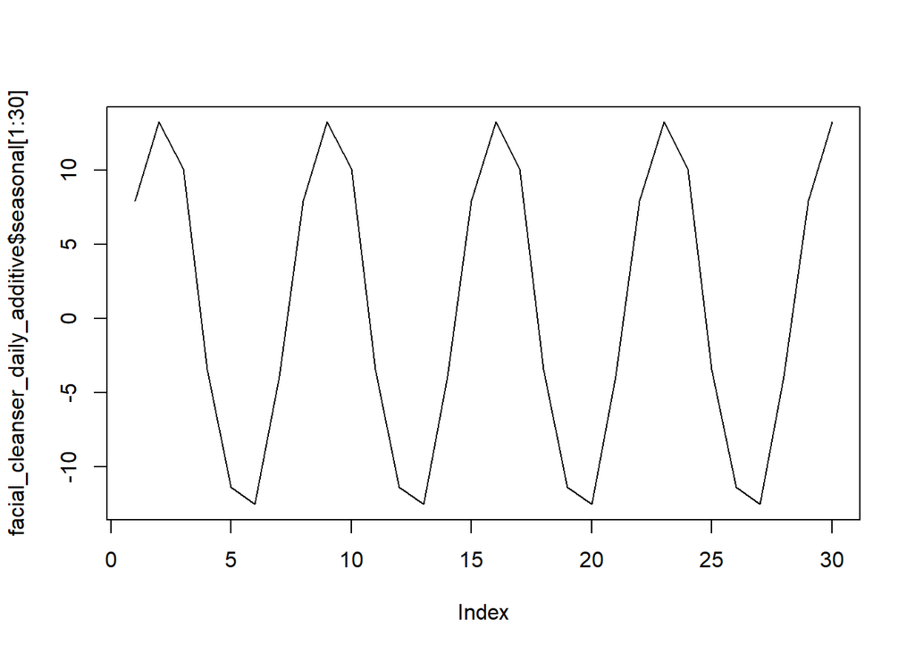

```r
plot(facial_cleanser_daily_additive$seasonal[1:30], type='l')
```

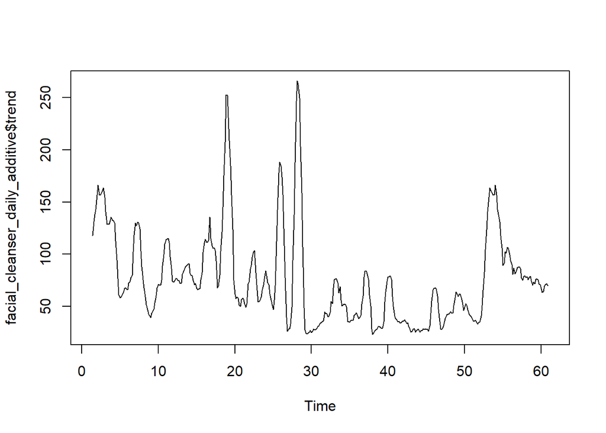

```r
plot(facial_cleanser_daily_additive$trend, type='l')
```

## ARIMA Model

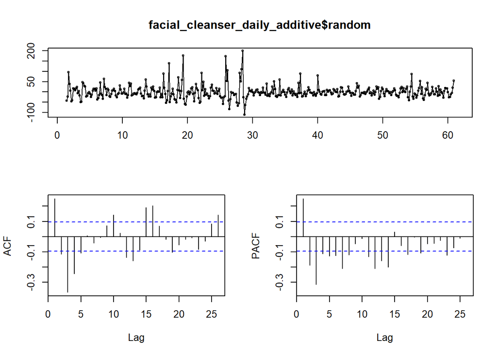

```r
tsdisplay(facial_cleanser_daily_additive$random, na.action = na.omit)
```

According to ACF plot, there is significant negative correlation at lag 3. Hence, moving average parameter should be 3. Also, it can be seen from PACF plot that correlation significantly decreased after lag 1 which means that AR parameter should be 1.

```r
facial_cleanser_model<-arima(facial_cleanser_daily_additive$random, order = c(1,0,3))
AIC(facial_cleanser_model)
```

```
## [1] 3926.859
```

```r
facial_cleanser_model2<-arima(facial_cleanser_daily_additive$random, order = c(1,0,2))
AIC(facial_cleanser_model2)
```

```
## [1] 3960.321
```

```r
facial_cleanser_model3<-arima(facial_cleanser_daily_additive$random, order = c(2,0,2))
AIC(facial_cleanser_model3)
```

```
## [1] 4017.71
```

When adjacent parameters also checked, still model 1 which has (1,0,3) parameters is better in terms of AIC values, therefore it is chosen.

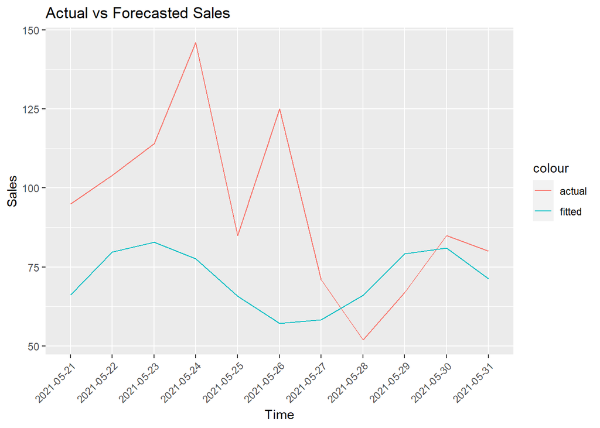

```r
model_forecast_error <- predict(facial_cleanser_model, n.ahead = 11)$pred
last_trend_value <-tail(facial_cleanser_daily_additive$trend[!is.na(facial_cleanser_daily_additive$trend)],1)
seasonality=facial_cleanser_daily_additive$seasonal[295:305]
facial_cleanser_arima_forecast=model_forecast_error+seasonality+last_trend_value
facial_cleanser_daily_te$forecast<-paste(facial_cleanser_arima_forecast)
facial_cleanser_daily_te$forecast<-as.numeric(facial_cleanser_daily_te$forecast)
ggplot(facial_cleanser_daily_te ,aes(x=event_date)) +
        geom_line(aes(y=sold_count,color='actual',group=1)) +
        geom_line(aes(y=forecast,color='fitted',group=1)) + labs(title = "Actual vs Forecasted Sales",
       x = "Time",
       y = "Sales"
       )+
 theme(axis.text.x = element_text(angle = 45, hjust=1))
```

The chart above shows the 11-day actual and estimated values with the ARIMA model we built on the decomposed random part.

```r
error_test(facial_cleanser_daily_te$sold_count,facial_cleanser_daily_te$forecast)
```

```
##    n     mean       sd      bias      mape      mad     wmape       MPE
## 1 11 93.09091 27.45343 0.2328076 0.2574653 26.45934 0.2842311 0.1749611
```

## Regressor Search

```r
facial_cleanser_lm1<-lm(sold_count~visit_count, data=facial_cleanser_daily_tr)
summary(facial_cleanser_lm1)
```

```
##
## Call:
## lm(formula = sold_count ~ visit_count, data = facial_cleanser_daily_tr)
##
## Residuals:
##    Min     1Q Median     3Q    Max
## -58.00 -29.49 -17.79   6.07 387.21
##
## Coefficients:
##              Estimate Std. Error t value Pr(>|t|)
## (Intercept) 59.787142   3.498379  17.090  < 2e-16 ***
## visit_count  0.009846   0.001208   8.148 4.27e-15 ***
## ---
## Signif. codes:  0 '***' 0.001 '**' 0.01 '*' 0.05 '.' 0.1 ' ' 1
##
## Residual standard error: 57.28 on 421 degrees of freedom
## Multiple R-squared:  0.1362, Adjusted R-squared:  0.1342
## F-statistic: 66.39 on 1 and 421 DF,  p-value: 4.27e-15
```

```r
facial_cleanser_lm2<-lm(sold_count~category_sold+price, data=facial_cleanser_daily_tr)
summary(facial_cleanser_lm2)
```

```
##
## Call:
## lm(formula = sold_count ~ category_sold + price, data = facial_cleanser_daily_tr)
##
## Residuals:
##     Min      1Q  Median      3Q     Max
## -127.39  -39.12  -16.12   19.08  307.19
##
## Coefficients:
##                 Estimate Std. Error t value Pr(>|t|)
## (Intercept)   322.885856  42.177263   7.655 1.34e-13 ***
## category_sold   0.020617   0.002619   7.872 3.00e-14 ***
## price          -3.327018   0.543551  -6.121 2.14e-09 ***
## ---
## Signif. codes:  0 '***' 0.001 '**' 0.01 '*' 0.05 '.' 0.1 ' ' 1
##
## Residual standard error: 56.81 on 420 degrees of freedom
## Multiple R-squared:  0.1522, Adjusted R-squared:  0.1482
## F-statistic:  37.7 on 2 and 420 DF,  p-value: 8.715e-16
```

```r
facial_cleanser_lm3<-lm(sold_count~price+favored_count+category_sold, data=facial_cleanser_daily_tr)
summary(facial_cleanser_lm3)
```

```
##
## Call:
## lm(formula = sold_count ~ price + favored_count + category_sold,
##     data = facial_cleanser_daily_tr)
##
## Residuals:
##     Min      1Q  Median      3Q     Max
## -177.21  -25.61   -6.91   13.99  334.68
##
## Coefficients:
##                 Estimate Std. Error t value Pr(>|t|)
## (Intercept)   455.699159  36.075634   12.63  < 2e-16 ***
## price          -5.350732   0.471226  -11.36  < 2e-16 ***
## favored_count   0.065720   0.004678   14.05  < 2e-16 ***
## category_sold   0.016290   0.002184    7.46 5.03e-13 ***
## ---
## Signif. codes:  0 '***' 0.001 '**' 0.01 '*' 0.05 '.' 0.1 ' ' 1
##
## Residual standard error: 46.9 on 419 degrees of freedom
## Multiple R-squared:  0.4237, Adjusted R-squared:  0.4196
## F-statistic: 102.7 on 3 and 419 DF,  p-value: < 2.2e-16
```

```r
facial_cleanser_lm4<-lm(sold_count~favored_count+basket_count+visit_count+category_sold, data=facial_cleanser_daily_tr)
summary(facial_cleanser_lm4)
```

```
##
## Call:
## lm(formula = sold_count ~ favored_count + basket_count + visit_count +
##     category_sold, data = facial_cleanser_daily_tr)
##
## Residuals:
##      Min       1Q   Median       3Q      Max
## -111.708  -10.541   -0.260    9.394  165.807
##
## Coefficients:
##                 Estimate Std. Error t value Pr(>|t|)
## (Intercept)   -1.375e+01  2.234e+00  -6.156 1.75e-09 ***
## favored_count -1.095e-02  3.452e-03  -3.173 0.001620 **
## basket_count   3.204e-01  7.889e-03  40.613  < 2e-16 ***
## visit_count   -1.647e-02  8.503e-04 -19.372  < 2e-16 ***
## category_sold  4.261e-03  1.114e-03   3.825 0.000151 ***
## ---
## Signif. codes:  0 '***' 0.001 '**' 0.01 '*' 0.05 '.' 0.1 ' ' 1
##
## Residual standard error: 24.14 on 418 degrees of freedom
## Multiple R-squared:  0.8477, Adjusted R-squared:  0.8462
## F-statistic: 581.6 on 4 and 418 DF,  p-value: < 2.2e-16
```

```r
facial_cleanser_daily_te$forecastlm1<-predict(facial_cleanser_lm1,facial_cleanser_daily_te)
facial_cleanser_daily_te$forecastlm2<-predict(facial_cleanser_lm2,facial_cleanser_daily_te)
facial_cleanser_daily_te$forecastlm3<-predict(facial_cleanser_lm3,facial_cleanser_daily_te)
facial_cleanser_daily_te$forecastlm4<-predict(facial_cleanser_lm4,facial_cleanser_daily_te)
error_test(facial_cleanser_daily_te$sold_count,facial_cleanser_daily_te$forecastlm1)
```

```
##    n     mean       sd       bias      mape    mad     wmape        MPE
## 1 11 93.09091 27.45343 -0.1610678 0.3179692 24.914 0.2676309 -0.2469022
```

```r
error_test(facial_cleanser_daily_te$sold_count,facial_cleanser_daily_te$forecastlm2)
```

```
##    n     mean       sd      bias      mape      mad     wmape       MPE
## 1 11 93.09091 27.45343 0.2885735 0.5161389 49.00427 0.5264131 0.2264891
```

```r
error_test(facial_cleanser_daily_te$sold_count,facial_cleanser_daily_te$forecastlm3)
```

```
##    n     mean       sd      bias      mape      mad     wmape       MPE
## 1 11 93.09091 27.45343 0.1049524 0.4340542 40.09367 0.4306937 0.0455137
```

```r
error_test(facial_cleanser_daily_te$sold_count,facial_cleanser_daily_te$forecastlm4)
```

```
##    n     mean       sd       bias      mape      mad     wmape         MPE
## 1 11 93.09091 27.45343 -0.0625795 0.2801064 27.41798 0.2945291 -0.08154591
```

## ARIMAX Model

```r
facial_cleanser_xreg1<-cbind(facial_cleanser_daily_tr$favored_count,
                  facial_cleanser_daily_tr$basket_count,
                  facial_cleanser_daily_tr$category_sold,
                  facial_cleanser_daily_tr$is.discount_days,
                  facial_cleanser_daily_tr$visit_count)
facial_cleanser_xreg2<-cbind(facial_cleanser_daily_te$favored_count,
                  facial_cleanser_daily_te$basket_count,
                  facial_cleanser_daily_te$category_sold,
                  facial_cleanser_daily_te$is.discount_days,
                  facial_cleanser_daily_te$visit_count)
facial_cleanser_arimax<-Arima(facial_cleanser_ts_daily,xreg=as.matrix(facial_cleanser_xreg1),order=c(1,0,3))
facial_cleanser_daily_te$forecastarimax<-forecast(facial_cleanser_arimax,xreg=as.matrix(facial_cleanser_xreg2))$mean
error_test(facial_cleanser_daily_te$sold_count,facial_cleanser_daily_te$forecastarimax)
```

```
##    n     mean       sd        bias      mape      mad     wmape         MPE
## 1 11 93.09091 27.45343 -0.06593391 0.2733503 26.58118 0.2855401 -0.09475903
```

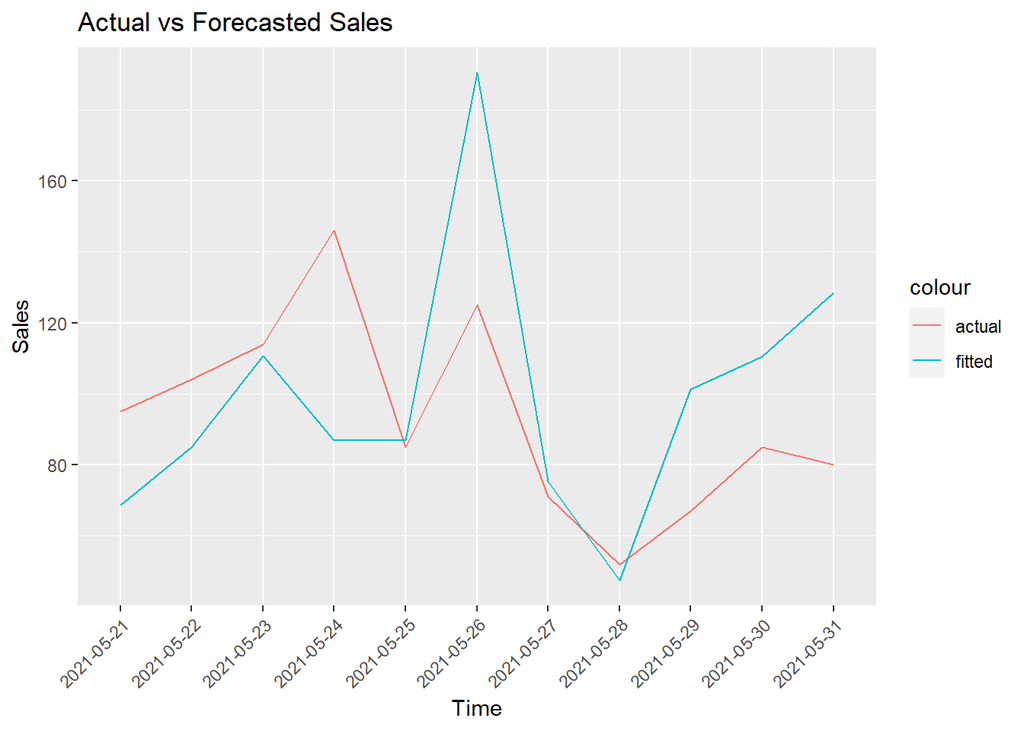

```r
ggplot(facial_cleanser_daily_te ,aes(x=event_date)) +
        geom_line(aes(y=sold_count,color='actual',group=1)) +
        geom_line(aes(y=forecastarimax,color='fitted',group=1)) + labs(title = "Actual vs Forecasted Sales",
       x = "Time",
       y = "Sales"
       )+
  theme(axis.text.x = element_text(angle = 45, hjust=1))
```

# Fakir Vacuum Cleaner

## Decomposition

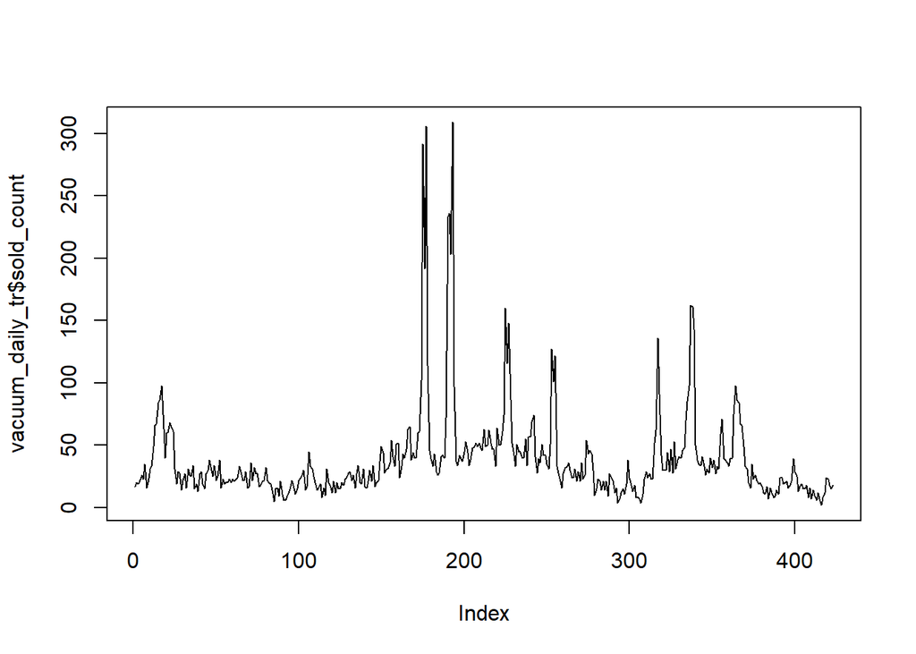

```r
vacuum<-subset(alldata, alldata$product_content_id==7061886)
vacuum_daily_tr<-vacuum[vacuum$event_date<"2021-05-21"]
vacuum_daily_te<-vacuum[vacuum$event_date>="2021-05-21"]
plot(vacuum_daily_tr$sold_count, type ='l')
```

Fakir vacuum cleaner daily sold count plot for given days can be seen above.

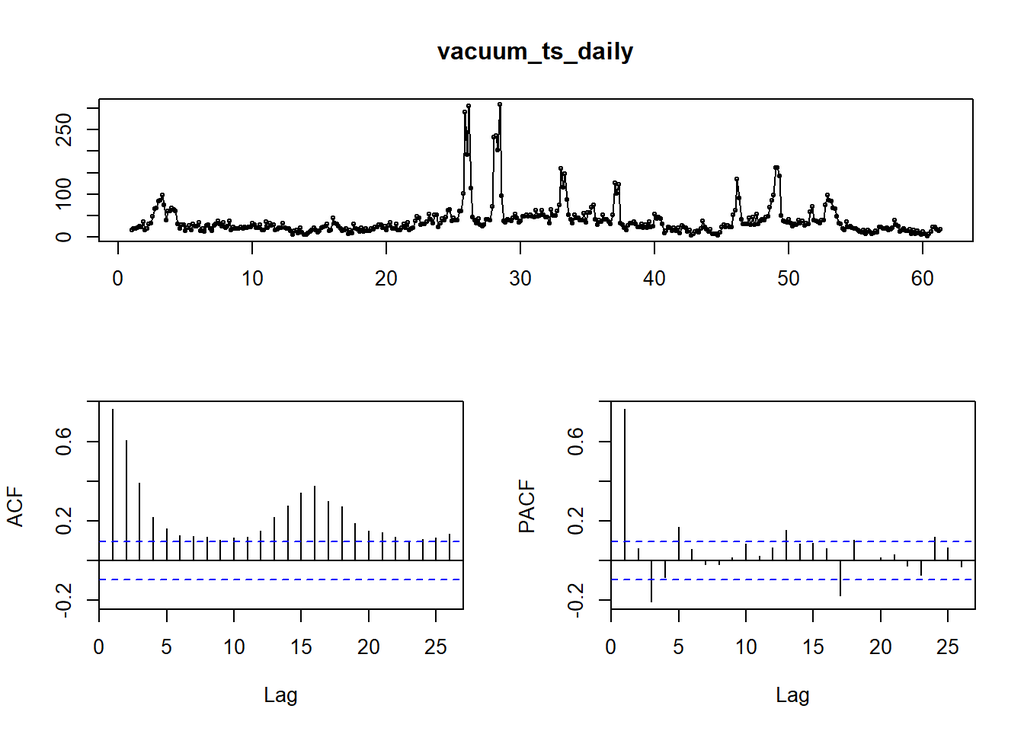

```r
vacuum_ts_daily<-ts(vacuum_daily_tr$sold_count, freq=7)
tsdisplay(vacuum_ts_daily)
```

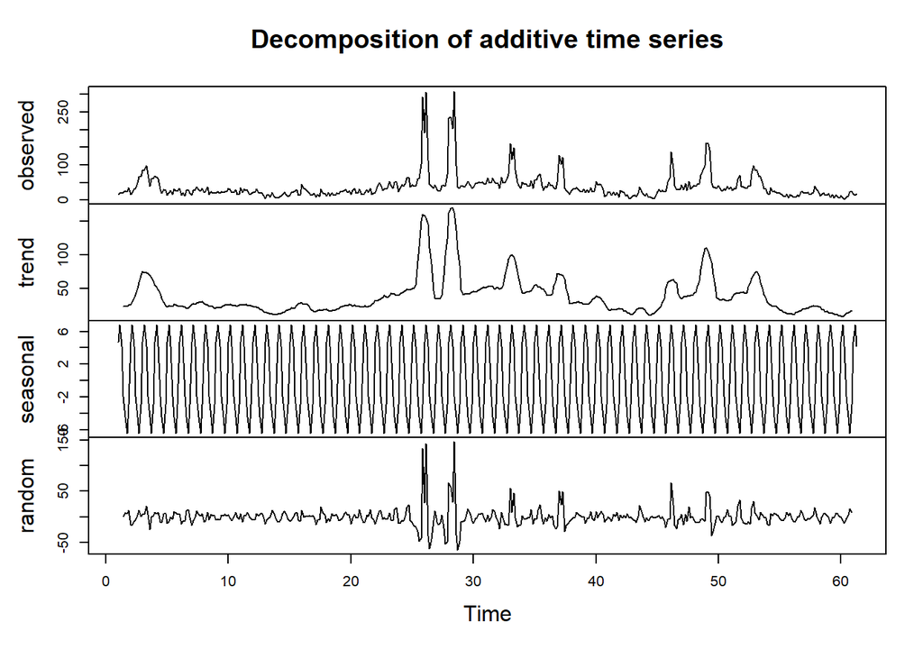

```r
vacuum_daily_additive<-decompose(vacuum_ts_daily, type ="additive")
vacuum_daily_multiplicative<-decompose(vacuum_ts_daily, type ="multiplicative")
plot(vacuum_daily_additive)
```

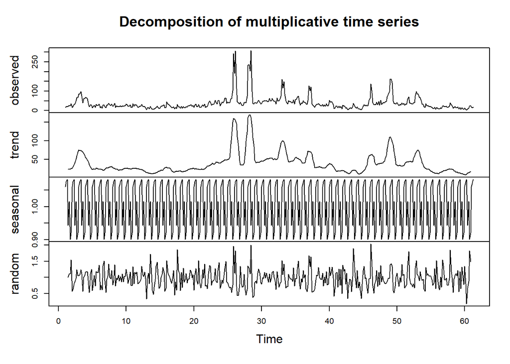

```r
plot(vacuum_daily_multiplicative)
```

The graphs above show the trend, seasonal and random components of the multiplicative and additive decomposition. Since there is 0 mean assumption in the continuation of the study, we will continue on the ‘additive’ model.

```r
test13=ur.kpss(vacuum_daily_additive$random, use.lag="7")
summary(test13)
```

```
##
## #######################
## # KPSS Unit Root Test #
## #######################
##
## Test is of type: mu with 7 lags.
##
## Value of test-statistic is: 0.0093
##
## Critical value for a significance level of:
##                 10pct  5pct 2.5pct  1pct
## critical values 0.347 0.463  0.574 0.739
```

```r
test14=ur.kpss(vacuum_daily_multiplicative$random, use.lag="7")
summary(test14)
```

```
##
## #######################
## # KPSS Unit Root Test #
## #######################
##
## Test is of type: mu with 7 lags.
##
## Value of test-statistic is: 0.0895
##
## Critical value for a significance level of:
##                 10pct  5pct 2.5pct  1pct
## critical values 0.347 0.463  0.574 0.739
```

We can see that the additive model is better by applying the kpss test.

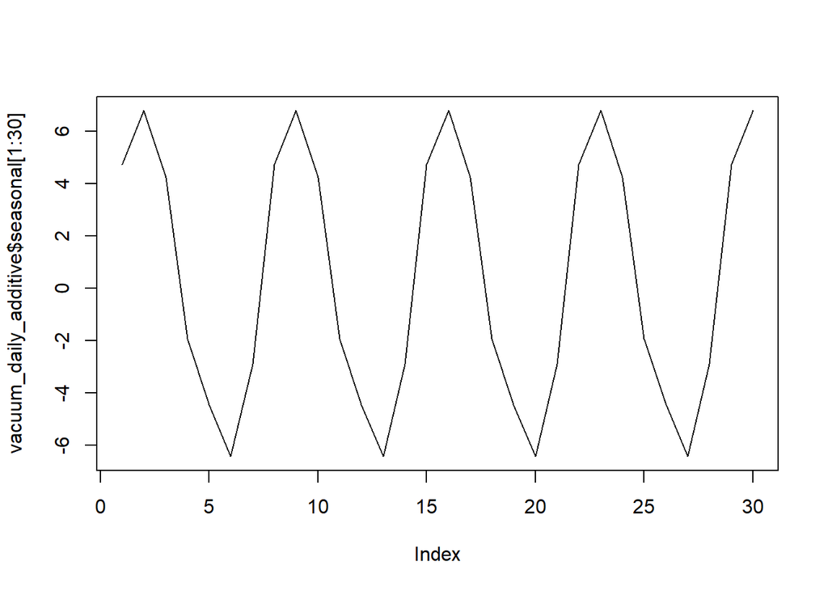

```r
plot(vacuum_daily_additive$seasonal[1:30], type='l')
```

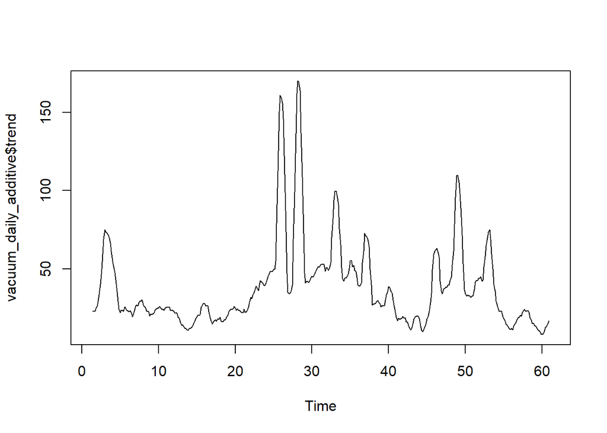

```r
plot(vacuum_daily_additive$trend, type='l')
```

## ARIMA Model

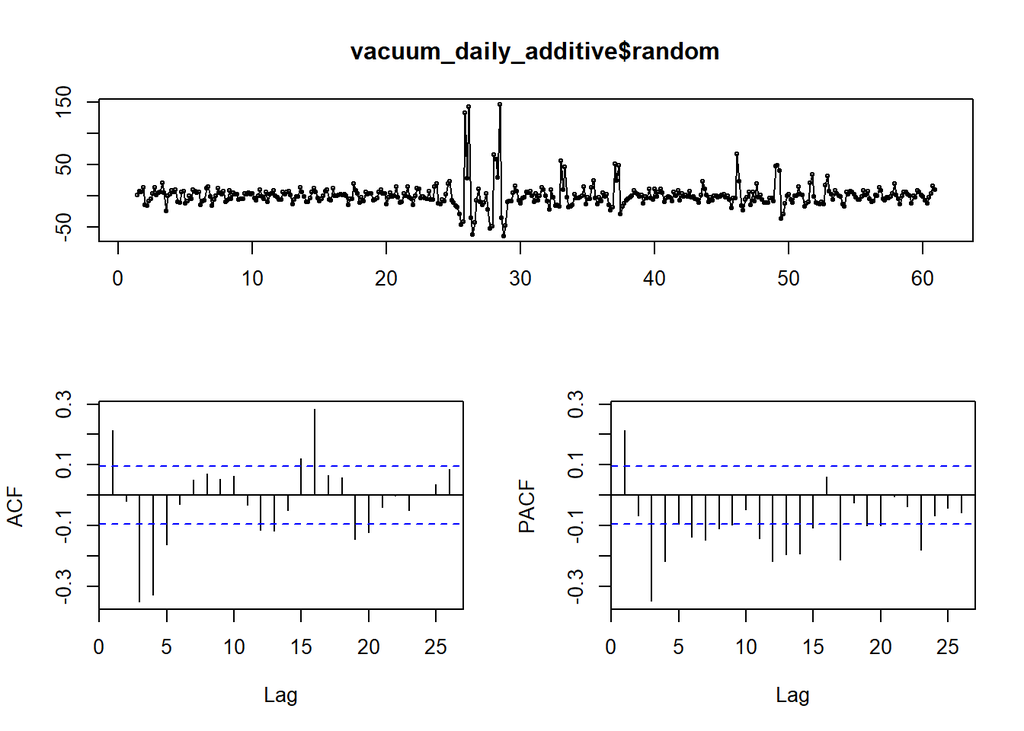

```r
tsdisplay(vacuum_daily_additive$random, na.action = na.omit)
```

According to ACF plot, there is significant negative correlation at lag 3. Hence, moving average parameter should be 3. Also, it can be seen from PACF plot that correlation significantly decreased after lag 1 which means that AR parameter should be 1.

```r
vacuum_model<-arima(vacuum_daily_additive$random, order = c(1,0,3))
AIC(vacuum_model)
```

```
## [1] 3506.971
```

```r
vacuum_model2<-arima(vacuum_daily_additive$random, order = c(1,0,2))
AIC(vacuum_model2)
```

```
## [1] 3624.003
```

```r
vacuum_model3<-arima(vacuum_daily_additive$random, order = c(2,0,2))
AIC(vacuum_model3)
```

```
## [1] 3471.33
```

When adjacent parameters also checked, still model 3 which has (2,0,2) parameters is better in terms of AIC values, therefore it is chosen.

Fitting the model

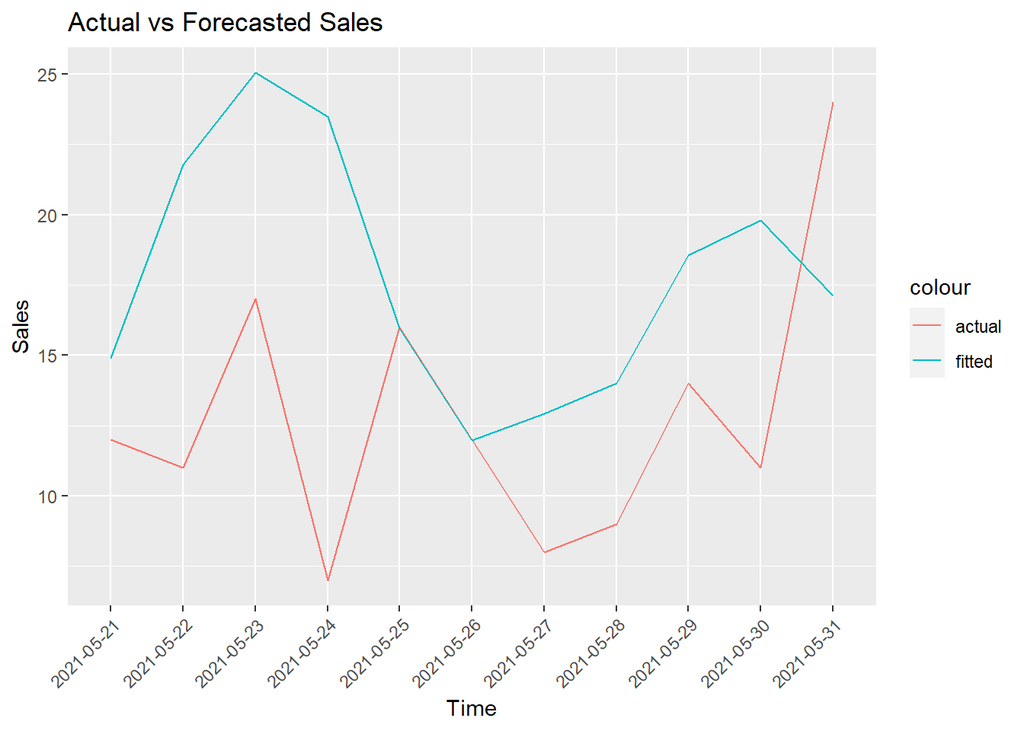

```r
model_forecast_error <- predict(vacuum_model3, n.ahead = 11)$pred
last_trend_value <-tail(vacuum_daily_additive$trend[!is.na(vacuum_daily_additive$trend)],1)
seasonality=vacuum_daily_additive$seasonal[295:305]
vacuum_arima_forecast=model_forecast_error+seasonality+last_trend_value
vacuum_daily_te$forecast<-paste(vacuum_arima_forecast)
vacuum_daily_te$forecast<-as.numeric(vacuum_daily_te$forecast)
ggplot(vacuum_daily_te ,aes(x=event_date)) +
        geom_line(aes(y=sold_count,color='actual', group=1)) +
        geom_line(aes(y=forecast,color='fitted', group=1)) + labs(title = "Actual vs Forecasted Sales",
       x = "Time",
       y = "Sales"
       )+
  theme(axis.text.x = element_text(angle = 45, hjust=1))
```

The chart above shows the 11-day actual and estimated values with the ARIMA model we built on the decomposed random part. Although the ARIMA model has seen ups and downs in sales, it doesn’t seem to explain it clearly.

```r
error_test(vacuum_daily_te$sold_count,vacuum_daily_te$forecast)
```

```
##    n     mean       sd       bias      mape     mad     wmape        MPE
## 1 11 12.81818 4.833595 -0.3870244 0.6035004 6.22155 0.4853691 -0.5507281
```

## Regressor Search

```r
vacuum_lm1<-lm(sold_count~visit_count, data=vacuum_daily_tr)
summary(vacuum_lm1)
```

```
##
## Call:
## lm(formula = sold_count ~ visit_count, data = vacuum_daily_tr)
##
## Residuals:
##     Min      1Q  Median      3Q     Max
## -36.591 -18.428  -9.428   3.572 269.572
##
## Coefficients:
##              Estimate Std. Error t value Pr(>|t|)
## (Intercept) 39.427728   2.217886  17.777   <2e-16 ***
## visit_count -0.001591   0.001543  -1.032    0.303
## ---
## Signif. codes:  0 '***' 0.001 '**' 0.01 '*' 0.05 '.' 0.1 ' ' 1
##
## Residual standard error: 37.73 on 421 degrees of freedom
## Multiple R-squared:  0.002522,   Adjusted R-squared:  0.0001524
## F-statistic: 1.064 on 1 and 421 DF,  p-value: 0.3028
```

```r
vacuum_lm2<-lm(sold_count~category_sold+price, data=vacuum_daily_tr)
summary(vacuum_lm2)
```

```
##
## Call:
## lm(formula = sold_count ~ category_sold + price, data = vacuum_daily_tr)
##
## Residuals:
##     Min      1Q  Median      3Q     Max
## -95.246 -16.932   2.861  10.239 197.337
##
## Coefficients:
##                 Estimate Std. Error t value Pr(>|t|)
## (Intercept)   215.492691  15.831716   13.61   <2e-16 ***
## category_sold   0.087324   0.006893   12.67   <2e-16 ***
## price          -0.743668   0.060912  -12.21   <2e-16 ***
## ---
## Signif. codes:  0 '***' 0.001 '**' 0.01 '*' 0.05 '.' 0.1 ' ' 1
##
## Residual standard error: 30.21 on 420 degrees of freedom
## Multiple R-squared:  0.3619, Adjusted R-squared:  0.3589
## F-statistic: 119.1 on 2 and 420 DF,  p-value: < 2.2e-16
```

```r
vacuum_lm3<-lm(sold_count~price+favored_count+category_sold, data=vacuum_daily_tr)
summary(vacuum_lm3)
```

```
##
## Call:
## lm(formula = sold_count ~ price + favored_count + category_sold,
##     data = vacuum_daily_tr)
##
## Residuals:
##      Min       1Q   Median       3Q      Max
## -102.227  -16.341    2.226   11.428  197.513
##
## Coefficients:
##                 Estimate Std. Error t value Pr(>|t|)
## (Intercept)   270.538510  18.436030  14.674  < 2e-16 ***
## price          -0.985604   0.074194 -13.284  < 2e-16 ***
## favored_count   0.077167   0.014355   5.376 1.27e-07 ***
## category_sold   0.091878   0.006728  13.655  < 2e-16 ***
## ---
## Signif. codes:  0 '***' 0.001 '**' 0.01 '*' 0.05 '.' 0.1 ' ' 1
##
## Residual standard error: 29.26 on 419 degrees of freedom
## Multiple R-squared:  0.4031, Adjusted R-squared:  0.3988
## F-statistic: 94.32 on 3 and 419 DF,  p-value: < 2.2e-16
```

```r
vacuum_lm4<-lm(sold_count~favored_count+basket_count+visit_count, data=vacuum_daily_tr)
summary(vacuum_lm4)
```

```
##
## Call:
## lm(formula = sold_count ~ favored_count + basket_count + visit_count,
##     data = vacuum_daily_tr)
##
## Residuals:
##      Min       1Q   Median       3Q      Max
## -140.177   -4.348   -0.159    4.465  140.854
##
## Coefficients:
##                Estimate Std. Error t value Pr(>|t|)
## (Intercept)   -0.728855   1.605887  -0.454   0.6502
## favored_count -0.039175   0.009812  -3.992 7.72e-05 ***
## basket_count   0.296271   0.007916  37.428  < 2e-16 ***
## visit_count    0.001778   0.001032   1.722   0.0857 .
## ---
## Signif. codes:  0 '***' 0.001 '**' 0.01 '*' 0.05 '.' 0.1 ' ' 1
##
## Residual standard error: 18.08 on 419 degrees of freedom
## Multiple R-squared:  0.772,  Adjusted R-squared:  0.7704
## F-statistic: 472.9 on 3 and 419 DF,  p-value: < 2.2e-16
```

```r
vacuum_daily_te$forecastlm1<-predict(vacuum_lm1,vacuum_daily_te)
vacuum_daily_te$forecastlm2<-predict(vacuum_lm2,vacuum_daily_te)
vacuum_daily_te$forecastlm3<-predict(vacuum_lm3,vacuum_daily_te)
vacuum_daily_te$forecastlm4<-predict(vacuum_lm4,vacuum_daily_te)
error_test(vacuum_daily_te$sold_count,vacuum_daily_te$forecastlm1)
```

```
##    n     mean       sd      bias     mape      mad    wmape       MPE
## 1 11 12.81818 4.833595 -1.920239 2.278859 24.61397 1.920239 -2.278859
```

```r
error_test(vacuum_daily_te$sold_count,vacuum_daily_te$forecastlm2)
```

```
##    n     mean       sd       bias     mape      mad    wmape        MPE
## 1 11 12.81818 4.833595 -0.6916955 1.450729 19.79588 1.544359 -0.4830142
```

```r
error_test(vacuum_daily_te$sold_count,vacuum_daily_te$forecastlm3)
```

```
##    n     mean       sd       bias     mape      mad    wmape       MPE
## 1 11 12.81818 4.833595 -0.0924969 2.010445 25.26139 1.970747 0.2425821
```

```r
error_test(vacuum_daily_te$sold_count,vacuum_daily_te$forecastlm4)
```

```
##    n     mean       sd       bias      mape      mad     wmape        MPE
## 1 11 12.81818 4.833595 -0.2606186 0.3747096 3.862429 0.3013242 -0.3529691
```

## ARIMAX Model

```r
vacuum_xreg1<-cbind(vacuum_daily_tr$favored_count,
                  vacuum_daily_tr$basket_count,
                  vacuum_daily_tr$visit_count)
vacuum_xreg2<-cbind(vacuum_daily_te$favored_count,
                  vacuum_daily_te$basket_count,
                  vacuum_daily_te$visit_count)
vacuum_arimax<-Arima(vacuum_ts_daily,xreg=as.matrix(vacuum_xreg1),order=c(2,0,2))
vacuum_daily_te$forecastarimax<-forecast(vacuum_arimax,xreg=as.matrix(vacuum_xreg2))$mean
error_test(vacuum_daily_te$sold_count,vacuum_daily_te$forecastarimax)
```

```
##    n     mean       sd       bias      mape      mad     wmape        MPE
## 1 11 12.81818 4.833595 -0.2789612 0.4165966 4.282942 0.3341303 -0.3871313
```

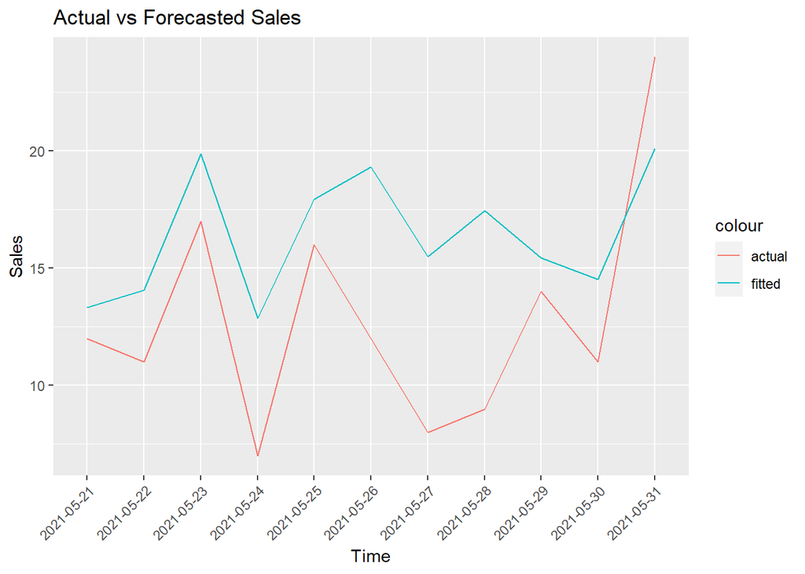

```r
ggplot(vacuum_daily_te ,aes(x=event_date)) +
        geom_line(aes(y=sold_count,color='actual', group=1)) +
        geom_line(aes(y=forecastarimax,color='fitted', group=1)) + labs(title = "Actual vs Forecasted Sales",
       x = "Time",
       y = "Sales"
       )+
 theme(axis.text.x = element_text(angle = 45, hjust=1))
```

# Xiaomi Bluetooth Earphone

## Decomposition

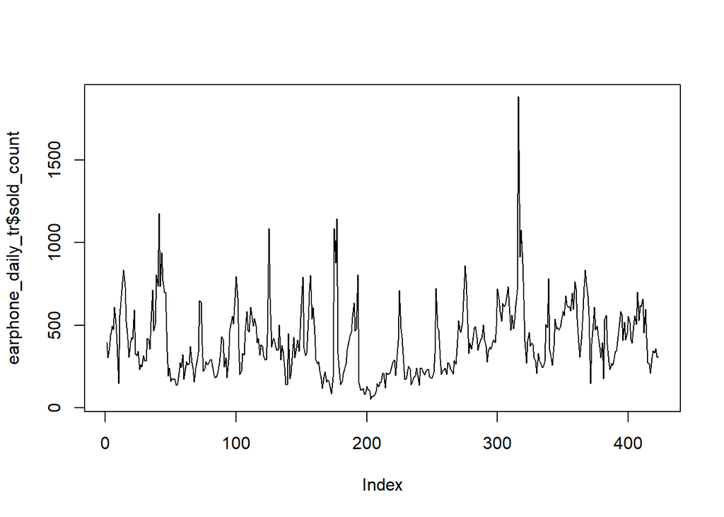

```r
earphone<-subset(alldata, alldata$product_content_id==6676673)
earphone_daily_tr<-earphone[earphone$event_date<"2021-05-21"]
earphone_daily_te<-earphone[earphone$event_date>="2021-05-21"]
plot(earphone_daily_tr$sold_count, type ='l')
```

Plot above shows sold counts of Xiaomi Bluetooth Earphone, which has no visible trend over time and variance seems constant, although there are outlier points.

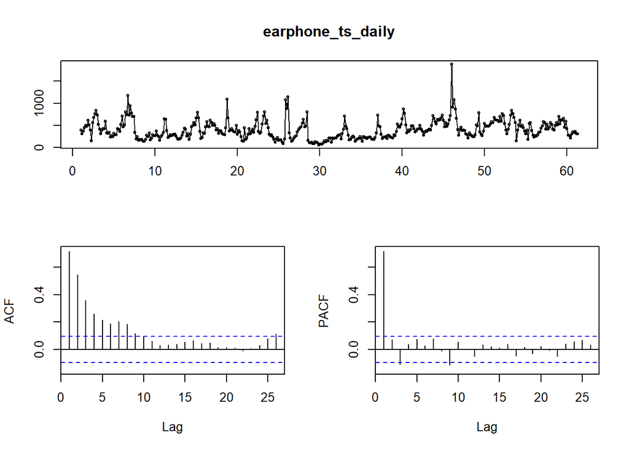

```r
earphone_ts_daily<-ts(earphone_daily_tr$sold_count, freq=7)
tsdisplay(earphone_ts_daily)
```

ACF plot shows significant correlation decreasing down to lag 8 and PACF shows only significant correlation at lag 1. It will be examined further after parsing.

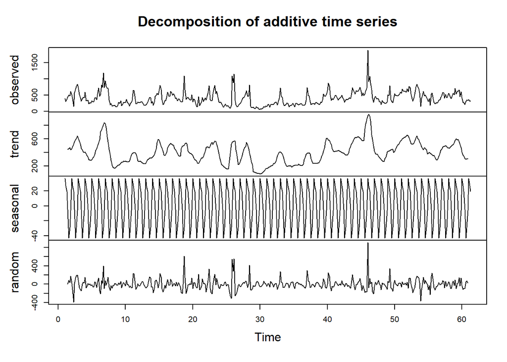

```r
earphone_daily_additive<-decompose(earphone_ts_daily, type ="additive")
earphone_daily_multiplicative<-decompose(earphone_ts_daily, type ="multiplicative")
plot(earphone_daily_additive)
```

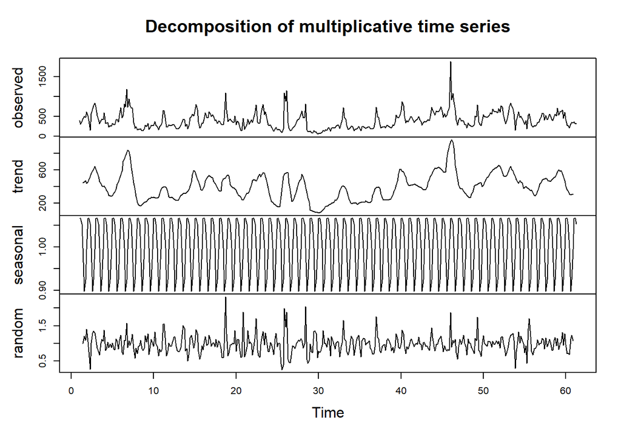

```r
plot(earphone_daily_multiplicative)
```

The graphs above show the trend, seasonal and random components of the multiplicative and additive decomposition. Since there is 0 mean assumption in the continuation of the study, we will continue on the ‘additive’ model.

```r
test11=ur.kpss(earphone_daily_additive$random, use.lag="7")
summary(test11)
```

```
##
## #######################
## # KPSS Unit Root Test #
## #######################
##
## Test is of type: mu with 7 lags.
##
## Value of test-statistic is: 0.0123
##
## Critical value for a significance level of:
##                 10pct  5pct 2.5pct  1pct
## critical values 0.347 0.463  0.574 0.739
```

```r
test12=ur.kpss(earphone_daily_multiplicative$random, use.lag="7")
summary(test12)
```

```
##
## #######################
## # KPSS Unit Root Test #
## #######################
##
## Test is of type: mu with 7 lags.
##
## Value of test-statistic is: 0.048
##
## Critical value for a significance level of:
##                 10pct  5pct 2.5pct  1pct
## critical values 0.347 0.463  0.574 0.739
```

We can see that the additive model is better by applying the kpss test.

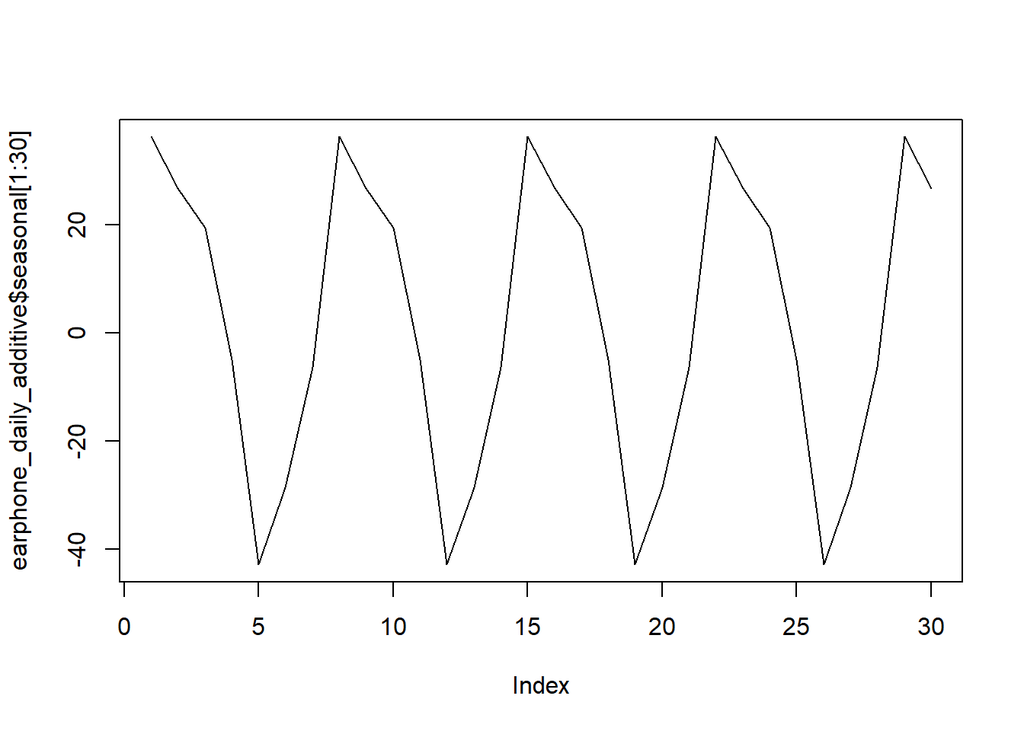

```r
plot(earphone_daily_additive$seasonal[1:30], type='l')
```

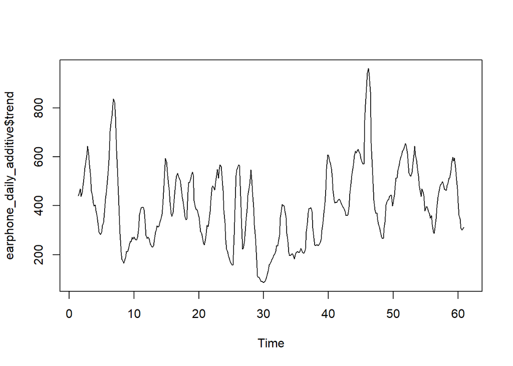

```r
plot(earphone_daily_additive$trend, type='l')
```

## ARIMA Model

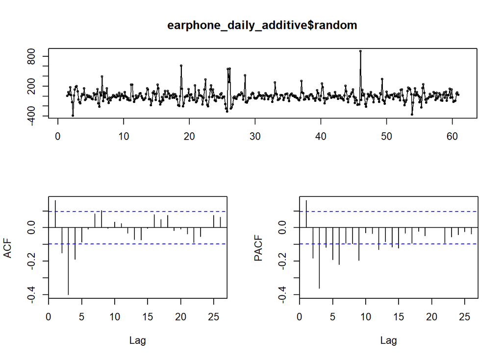

```r
tsdisplay(earphone_daily_additive$random, na.action = na.omit)
```

According to ACF plot, there is significant negative correlation at lag 3. Hence, moving average parameter should be 3. Also, it can be seen from PACF plot that correlation significantly decreased after lag 3 which means that AR parameter should be 3.

```r
earphone_model<-arima(earphone_daily_additive$random, order = c(3,0,3))
AIC(earphone_model)
```

```
## [1] 5005.451
```

```r
earphone_model2<-arima(earphone_daily_additive$random, order = c(3,0,2))
AIC(earphone_model2)
```

```
## [1] 5003.372
```

```r
earphone_model3<-arima(earphone_daily_additive$random, order = c(2,0,2))
AIC(earphone_model3)
```

```
## [1] 5007.554
```

When adjacent parameters also checked, model 2 which has (3,0,2) parameters is better in terms of AIC values, therefore it is chosen.

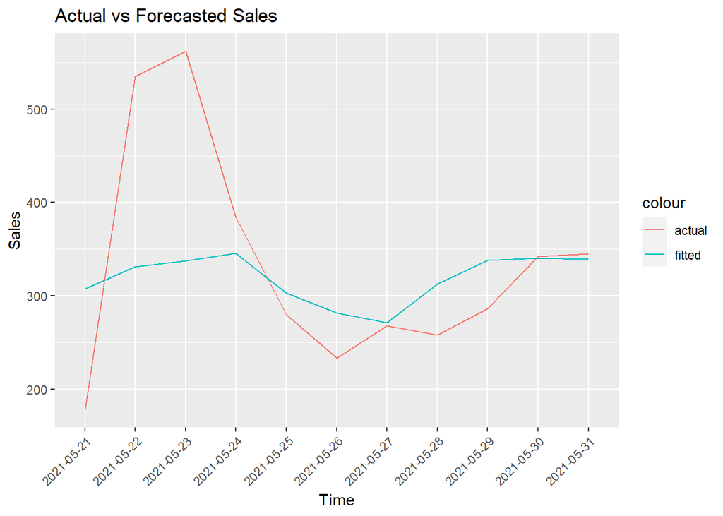

```r
model_forecast_error <- predict(earphone_model2, n.ahead = 11)$pred
last_trend_value <-tail(earphone_daily_additive$trend[!is.na(earphone_daily_additive$trend)],1)
seasonality=earphone_daily_additive$seasonal[295:305]
earphone_arima_forecast=model_forecast_error+seasonality+last_trend_value
earphone_daily_te$forecast<-paste(earphone_arima_forecast)
earphone_daily_te$forecast<-as.numeric(earphone_daily_te$forecast)
ggplot(earphone_daily_te ,aes(x=event_date)) +
        geom_line(aes(y=sold_count,color='actual', group=1)) +
        geom_line(aes(y=forecast,color='fitted', group=1)) + labs(title = "Actual vs Forecasted Sales",
       x = "Time",
       y = "Sales"
       )+
 theme(axis.text.x = element_text(angle = 45, hjust=1))
```

```r
error_test(earphone_daily_te$sold_count,earphone_daily_te$forecast)
```

```
##    n     mean       sd       bias      mape      mad     wmape         MPE
## 1 11 333.7273 120.3986 0.04440869 0.2114648 71.37532 0.2138732 -0.04747086
```

## Regressor Search

```r
earphone_lm1<-lm(sold_count~visit_count, data=earphone_daily_tr)
summary(earphone_lm1)
```

```
##
## Call:
## lm(formula = sold_count ~ visit_count, data = earphone_daily_tr)
##
## Residuals:
##     Min      1Q  Median      3Q     Max
## -327.22 -150.26  -36.86  115.44 1520.44
##
## Coefficients:
##              Estimate Std. Error t value Pr(>|t|)
## (Intercept) 3.626e+02  1.235e+01  29.360  < 2e-16 ***
## visit_count 4.812e-03  8.989e-04   5.353 1.43e-07 ***
## ---
## Signif. codes:  0 '***' 0.001 '**' 0.01 '*' 0.05 '.' 0.1 ' ' 1
##
## Residual standard error: 205.4 on 421 degrees of freedom
## Multiple R-squared:  0.06372,    Adjusted R-squared:  0.0615
## F-statistic: 28.65 on 1 and 421 DF,  p-value: 1.426e-07
```

```r
earphone_lm2<-lm(sold_count~category_sold+price, data=earphone_daily_tr)
summary(earphone_lm2)
```

```
##
## Call:
## lm(formula = sold_count ~ category_sold + price, data = earphone_daily_tr)
##
## Residuals:
##     Min      1Q  Median      3Q     Max
## -381.29 -110.41  -25.23   80.25 1328.13
##
## Coefficients:
##                 Estimate Std. Error t value Pr(>|t|)
## (Intercept)    1.444e+03  1.121e+02  12.885   <2e-16 ***
## category_sold  5.788e-03  8.334e-03   0.694    0.488
## price         -7.778e+00  7.866e-01  -9.889   <2e-16 ***
## ---
## Signif. codes:  0 '***' 0.001 '**' 0.01 '*' 0.05 '.' 0.1 ' ' 1
##
## Residual standard error: 182.9 on 420 degrees of freedom
## Multiple R-squared:  0.2589, Adjusted R-squared:  0.2553
## F-statistic: 73.34 on 2 and 420 DF,  p-value: < 2.2e-16
```

```r
earphone_lm3<-lm(sold_count~price+favored_count+category_sold, data=earphone_daily_tr)
summary(earphone_lm3)
```

```
##
## Call:
## lm(formula = sold_count ~ price + favored_count + category_sold,
##     data = earphone_daily_tr)
##
## Residuals:
##     Min      1Q  Median      3Q     Max
## -379.44 -104.22  -28.13   66.15 1355.25
##
## Coefficients:
##                 Estimate Std. Error t value Pr(>|t|)
## (Intercept)   1378.81979  115.19580  11.969   <2e-16 ***
## price           -7.40795    0.79986  -9.262   <2e-16 ***
## favored_count    0.02411    0.01071   2.251   0.0249 *
## category_sold    0.00361    0.00835   0.432   0.6657
## ---
## Signif. codes:  0 '***' 0.001 '**' 0.01 '*' 0.05 '.' 0.1 ' ' 1
##
## Residual standard error: 182 on 419 degrees of freedom
## Multiple R-squared:  0.2677, Adjusted R-squared:  0.2625
## F-statistic: 51.06 on 3 and 419 DF,  p-value: < 2.2e-16
```

```r
earphone_lm4<-lm(sold_count~favored_count+basket_count+visit_count, data=earphone_daily_tr)
summary(earphone_lm4)
```

```
##
## Call:
## lm(formula = sold_count ~ favored_count + basket_count + visit_count,
##     data = earphone_daily_tr)
##
## Residuals:
##     Min      1Q  Median      3Q     Max
## -691.77  -40.61    3.23   57.69  347.53
##
## Coefficients:
##                 Estimate Std. Error t value Pr(>|t|)
## (Intercept)   18.5530454 12.1844648   1.523  0.12859
## favored_count -0.0241866  0.0083515  -2.896  0.00398 **
## basket_count   0.2578856  0.0077545  33.256  < 2e-16 ***
## visit_count    0.0001352  0.0006479   0.209  0.83485
## ---
## Signif. codes:  0 '***' 0.001 '**' 0.01 '*' 0.05 '.' 0.1 ' ' 1
##
## Residual standard error: 107.3 on 419 degrees of freedom
## Multiple R-squared:  0.7456, Adjusted R-squared:  0.7438
## F-statistic: 409.3 on 3 and 419 DF,  p-value: < 2.2e-16
```

```r
earphone_daily_te$forecastlm1<-predict(earphone_lm1,earphone_daily_te)
earphone_daily_te$forecastlm2<-predict(earphone_lm2,earphone_daily_te)
earphone_daily_te$forecastlm3<-predict(earphone_lm3,earphone_daily_te)
earphone_daily_te$forecastlm4<-predict(earphone_lm4,earphone_daily_te)
error_test(earphone_daily_te$sold_count,earphone_daily_te$forecastlm1)
```

```
##    n     mean       sd       bias      mape      mad     wmape        MPE
## 1 11 333.7273 120.3986 -0.3442572 0.5245098 137.6828 0.4125608 -0.4830939
```

```r
error_test(earphone_daily_te$sold_count,earphone_daily_te$forecastlm2)
```

```
##    n     mean       sd       bias      mape      mad     wmape        MPE
## 1 11 333.7273 120.3986 -0.5123799 0.6640994 170.9951 0.5123799 -0.6640994
```

```r
error_test(earphone_daily_te$sold_count,earphone_daily_te$forecastlm3)
```

```
##    n     mean       sd       bias      mape      mad     wmape        MPE
## 1 11 333.7273 120.3986 -0.5130612 0.6609117 171.2225 0.5130612 -0.6609117
```

```r
error_test(earphone_daily_te$sold_count,earphone_daily_te$forecastlm4)
```

```
##    n     mean       sd        bias      mape      mad     wmape        MPE
## 1 11 333.7273 120.3986 -0.02354095 0.2037086 48.52136 0.1453922 -0.1020104
```

4 different multiple linear regression model is built to understand which regressors are explaining model better. In terms of adjusted R square and WMAPE 4th model is explaining sales behavior better than others. Therefore, 4th model’s regressors will be chosen which are favored count, basket count and visit count.

## ARIMAX Model

```r
earphone_xreg1<-cbind(earphone_daily_tr$favored_count,
                  earphone_daily_tr$basket_count,
                  earphone_daily_tr$visit_count)
earphone_xreg2<-cbind(earphone_daily_te$favored_count,
                  earphone_daily_te$basket_count,
                  earphone_daily_te$visit_count)
earphone_arimax<-Arima(earphone_ts_daily,xreg=as.matrix(earphone_xreg1),order=c(3,0,2))
earphone_daily_te$forecastarimax<-forecast(earphone_arimax,xreg=as.matrix(earphone_xreg2))$mean
error_test(earphone_daily_te$sold_count,earphone_daily_te$forecastarimax)
```

```
##    n     mean       sd       bias      mape      mad     wmape        MPE
## 1 11 333.7273 120.3986 -0.1405139 0.2806907 66.21114 0.1983989 -0.2436551
```

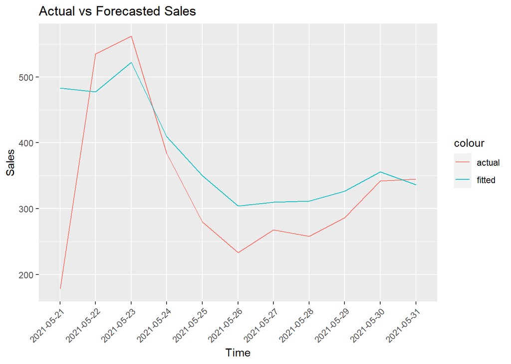

```r
ggplot(earphone_daily_te ,aes(x=event_date)) +
        geom_line(aes(y=sold_count,color='actual', group=1)) +
        geom_line(aes(y=forecastarimax,color='fitted',group=1)) + labs(title = "Actual vs Forecasted Sales",
       x = "Time",
       y = "Sales"
       )+
 theme(axis.text.x = element_text(angle = 45, hjust=1))
```

# Conclusion

A variety of product data from Trendyol is used to build forecasting models in this assignment. Decomposition of these goods is shown from trends and seasonal factors. In order to achieve this, the evaluation of random components of the goods is required relating to autocorrelation plots to decide on the most suitable ARIMA model. According on WMAPE values, possible regressors are examined and included to this ARIMA. So, the results of models are in a good level and these models will be used for big number of sales. We made certain assumptions such as naïve which is choosing the last trend value and regressor values from test set. In order to make more accurate predictions, the future price of goods that will be forecasted is needed. Besides, the given data is missing, which makes forecasting almost impossible.